# Tarea 4 - Mineria de Datos e Inteligencia de Negocios

Jonathan Gonzalez, Gonzalo Rodriguez, Juan P. Villalobos

05/17/2020

# Web Mining y Clustering

## Objetivos

### Negocio

- Ejercicio Académico.

> Construir clusters de los jugadores mas valiosos de la NBA segun su porcentaje de efectividad en tiros.

### Minería de Datos

- Desarrollar un modelo utilizando reglas de clustering.
- Aplicar parcialmente la metodología CRISP-DM para resolver un caso básico de minería de datos.
- Extraer datos de una página web para ser analizados posteriormente.
- Aplicar expresiones regulares para procesar datos textuales.
- Aplicar un algoritmo de clustering a los datos extraídos.

### Criterio de éxito

- Aplicar los conceptos vistos en clase correctamente.

## Entendimiento de los datos

### Exploración de datos

- *Busque en Internet una página web con datos que sean de su interés. Los datos deben ser parte de lo que la página presenta, es decir, deben ser tablas, párrafos, etc. visibles al cargar la página.*

Para la presente tarea se utilizarán las siguientes páginas web:

- Estadísticas de los jugadores mas valiosos de la NBA y ABA (MVPs) según Basketball Reference: https://www.basketball-reference.com/awards/mvp.html
- Información de jugadores mas valiosos de la NBA (MVPs) según Wikipedia: https://en.wikipedia.org/wiki/NBA_Most_Valuable_Player_Award

```r
#leer los datos en formato html desde las paginas web, Wiki Basketball MVP
NBA_MVP_pageURL<-'https://www.basketball-reference.com/awards/mvp.html'
Wiki_MVP_pageURL<-'https://en.wikipedia.org/wiki/NBA_Most_Valuable_Player_Award'
nba_pageHTML<- read_html(NBA_MVP_pageURL,encoding = 'UTF-8')
wiki_pageHTML<- read_html(Wiki_MVP_pageURL,encoding = 'UTF-8')

#extraer las tablas del codigo html
nba_pageTables<- html_table(nba_pageHTML,fill=TRUE)
wiki_pageTables<- html_table(wiki_pageHTML,fill=TRUE)
```

#### Exploración de datos de www.basketball-reference.com

La página de Basketball Reference tiene: `3` tablas, cuyos encabezados son:

```r
#mostrar los encabezados de cada tabla
str(nba_pageTables)
```

```
## List of 3
##  $ :'data.frame':    65 obs. of  18 variables:
##   ..$         : chr [1:65] "Season" "2018-19" "2017-18" "2016-17" ...
##   ..$         : chr [1:65] "Lg" "NBA" "NBA" "NBA" ...
##   ..$         : chr [1:65] "Player" "Giannis Antetokounmpo" "James Harden" "Russell Westbrook" ...
##   ..$         : chr [1:65] "Voting" "(V)" "(V)" "(V)" ...
##   ..$         : chr [1:65] "Age" "24" "28" "28" ...
##   ..$         : chr [1:65] "Tm" "MIL" "HOU" "OKC" ...
##   ..$         : chr [1:65] "G" "72" "72" "81" ...
##   ..$ Per Game: chr [1:65] "MP" "32.8" "35.4" "34.6" ...
##   ..$ Per Game: chr [1:65] "PTS" "27.7" "30.4" "31.6" ...
##   ..$ Per Game: chr [1:65] "TRB" "12.5" "5.4" "10.7" ...
##   ..$ Per Game: chr [1:65] "AST" "5.9" "8.8" "10.4" ...
##   ..$ Per Game: chr [1:65] "STL" "1.3" "1.8" "1.6" ...
##   ..$ Per Game: chr [1:65] "BLK" "1.5" "0.7" "0.4" ...
##   ..$ Shooting: chr [1:65] "FG%" ".578" ".449" ".425" ...
##   ..$ Shooting: chr [1:65] "3P%" ".256" ".367" ".343" ...
##   ..$ Shooting: chr [1:65] "FT%" ".729" ".858" ".845" ...
##   ..$ Advanced: chr [1:65] "WS" "14.4" "15.4" "13.1" ...
##   ..$ Advanced: chr [1:65] "WS/48" ".292" ".289" ".224" ...
##  $ :'data.frame':    11 obs. of  18 variables:
##   ..$         : chr [1:11] "Season" "1975-76" "1974-75" "1974-75" ...
##   ..$         : chr [1:11] "Lg" "ABA" "ABA" "ABA" ...
##   ..$         : chr [1:11] "Player" "Julius Erving" "Julius Erving (Tie)" "George McGinnis (Tie)" ...
##   ..$         : chr [1:11] "Voting" "(V)" "(V)" "(V)" ...
##   ..$         : chr [1:11] "Age" "25" "24" "24" ...
##   ..$         : chr [1:11] "Tm" "NYA" "NYA" "INA" ...
##   ..$         : chr [1:11] "G" "84" "84" "79" ...
##   ..$ Per Game: chr [1:11] "MP" "38.6" "40.5" "40.4" ...
##   ..$ Per Game: chr [1:11] "PTS" "29.3" "27.9" "29.8" ...
##   ..$ Per Game: chr [1:11] "TRB" "11.0" "10.9" "14.3" ...
##   ..$ Per Game: chr [1:11] "AST" "5.0" "5.5" "6.3" ...
##   ..$ Per Game: chr [1:11] "STL" "2.5" "2.2" "2.6" ...
##   ..$ Per Game: chr [1:11] "BLK" "1.9" "1.9" "0.7" ...
##   ..$ Shooting: chr [1:11] "FG%" ".507" ".506" ".451" ...
##   ..$ Shooting: chr [1:11] "3P%" ".330" ".333" ".354" ...
##   ..$ Shooting: chr [1:11] "FT%" ".801" ".799" ".724" ...
##   ..$ Advanced: chr [1:11] "WS" "17.7" "17.6" "11.6" ...
##   ..$ Advanced: chr [1:11] "WS/48" ".262" ".248" ".174" ...
##  $ :'data.frame':    41 obs. of  3 variables:
##   ..$ Player: chr [1:41] "Kareem Abdul-Jabbar" "Michael Jordan" "Bill Russell" "Wilt Chamberlain" ...
##   ..$ Lg    : chr [1:41] "NBA" "NBA" "NBA" "NBA" ...
##   ..$ Count : int [1:41] 6 5 5 4 4 3 3 3 3 2 ...
```

La cantidad de datos vacíos en la tabla #1 es: `60`  
La cantidad de datos vacíos en la tabla #2 es: `11`

> Esta cantidad de datos vacíos nos indica que los datos deben limpiarse un poco antes de ser procesados.

#### Exploración de datos de Wikipedia

La página de NBA tiene: `9` tablas, cuyos encabezados son:

```r
#mostrar los encabezados de cada tabla
str(wiki_pageTables)
```

```
## List of 9
##  $ :'data.frame':    10 obs. of  3 variables:
##   ..$ National Basketball Association awards and honors: chr [1:10] "Championship" "Larry O'Brien Trophy \n\n\n\nBrown Trophy (defunct)" "Larry O'Brien Trophy" "Individual awards" ...
##   ..$ NA                                               : chr [1:10] NA "Larry O'Brien Trophy" "Brown Trophy (defunct)" NA ...
##   ..$ NA                                               : chr [1:10] NA "Brown Trophy (defunct)" NA NA ...
##  $ :'data.frame':    1 obs. of  2 variables:
##   ..$ X1: chr "Larry O'Brien Trophy"
##   ..$ X2: chr "Brown Trophy (defunct)"
##  $ :'data.frame':    1 obs. of  2 variables:
##   ..$ X1: chr "All-Star Game MVP\nCoach of the Year\nCommunity Assist Award\nDefensive Player of the Year\nExecutive of the Ye"| __truncated__
##   ..$ X2: chr "Most Improved Player\nMost Valuable Player\nRookie of the Year\nSixth Man of the Year\nSportsmanship Award\nTwy"| __truncated__
##  $ :'data.frame':    1 obs. of  2 variables:
##   ..$ X1: chr "All-NBA Team\nAll-Rookie Team"
##   ..$ X2: chr "All-Defensive Team"
##  $ :'data.frame':    5 obs. of  2 variables:
##   ..$ X1: chr [1:5] "^" "*" "" "Player (X)" ...
##   ..$ X2: chr [1:5] "Denotes player who is still active in the NBA" "Inducted into the Naismith Memorial Basketball Hall of Fame" "Denotes player whose team won championship that year" "Denotes the number of times the player had been named MVP at that time" ...
##  $ :'data.frame':    64 obs. of  5 variables:
##   ..$ Season     : chr [1:64] "1955–56" "1956–57" "1957–58" "1958–59" ...
##   ..$ Player     : chr [1:64] "Bob Pettit*" "Bob Cousy*" "Bill Russell*" "Bob Pettit* (2)" ...
##   ..$ Position   : chr [1:64] "Power forward" "Point guard" "Center" "Power forward" ...
##   ..$ Nationality: chr [1:64] "United States" "United States" "United States" "United States" ...
##   ..$ Team       : chr [1:64] "St. Louis Hawks" "Boston Celtics" "Boston Celtics (2)" "St. Louis Hawks (2)" ...
##  $ :'data.frame':    13 obs. of  4 variables:
##   ..$ Awards : int [1:13] 6 5 5 4 4 3 3 3 2 2 ...
##   ..$ Player : chr [1:13] "Kareem Abdul-Jabbar" "Bill Russell" "Michael Jordan" "Wilt Chamberlain" ...
##   ..$ Team(s): chr [1:13] "Milwaukee Bucks (3) / Los Angeles Lakers (3)" "Boston Celtics" "Chicago Bulls" "Philadelphia Warriors (1) / Philadelphia 76ers (3)" ...
##   ..$ Years  : chr [1:13] "1971, 1972, 1974, 1976, 1977, 1980" "1958, 1961, 1962, 1963, 1965" "1988, 1991, 1992, 1996, 1998" "1960, 1966, 1967, 1968" ...
##  $ :'data.frame':    21 obs. of  3 variables:
##   ..$ Awards: int [1:21] 10 8 6 6 4 4 3 3 3 2 ...
##   ..$ Teams : chr [1:21] "Boston Celtics" "Los Angeles Lakers" "Philadelphia 76ers" "Chicago Bulls" ...
##   ..$ Years : chr [1:21] "1957, 1958, 1961, 1962, 1963, 1965, 1973, 1984, 1985, 1986" "1976, 1977, 1980, 1987, 1989, 1990, 2000, 2008" "1966, 1967, 1968, 1981, 1983, 2001" "1988, 1991, 1992, 1996, 1998, 2011" ...
##  $ :'data.frame':    1 obs. of  2 variables:
##   ..$ vteNBA Most Valuable Player Award: chr "1956: Pettit\n1957: Cousy\n1958: Russell\n1959: Pettit\n1960: Chamberlain\n1961: Russell\n1962: Russell\n1963: "| __truncated__
##   ..$ vteNBA Most Valuable Player Award: chr "1956: Pettit\n1957: Cousy\n1958: Russell\n1959: Pettit\n1960: Chamberlain\n1961: Russell\n1962: Russell\n1963: "| __truncated__
```

> El resultado anterior nos muestra que los datos a extraer están en la tabla número 6 y que sus encabezados no necesitan limpieza adicional.

La cantidad de datos vacios en la tabla #6 es: `0`

> Esta cantidad de datos vacios nos indica una alta calidad en los datos.

### Preparación de los datos

- *Seleccione los datos de su interés en las páginas previamente identificadas.*

```r
#agregar y almacenar la tablas #1 y #2 de la NBA
nba_Table<- nba_pageTables[[1]]

#seleccionar la primera fila como encabezados.
names(nba_Table) <- nba_Table[1,]

#almacenar la tabla #3 de la pagina de Wiki, no necesita cambios por el momento.
wiki_Table<- wiki_pageTables[[6]]

kable(nba_Table)
```

Player

Voting

Age

Tm

G

MP

PTS

TRB

AST

STL

BLK

FG%

3P%

FT%

WS

WS/48

Season

Lg

Player

Voting

Age

Tm

G

MP

PTS

TRB

AST

STL

BLK

FG%

3P%

FT%

WS

WS/48

2018-19

NBA

Giannis Antetokounmpo

24

MIL

72

32.8

27.7

12.5

5.9

1.3

1.5

.578

.256

.729

14.4

.292

2017-18

NBA

James Harden

28

HOU

72

35.4

30.4

5.4

8.8

1.8

0.7

.449

.367

.858

15.4

.289

2016-17

NBA

Russell Westbrook

28

OKC

81

34.6

31.6

10.7

10.4

1.6

0.4

.425

.343

.845

13.1

.224

2015-16

NBA

Stephen Curry

27

GSW

79

34.2

30.1

5.4

6.7

2.1

0.2

.504

.454

.908

17.9

.318

2014-15

NBA

Stephen Curry

26

GSW

80

32.7

23.8

4.3

7.7

2.0

0.2

.487

.443

.914

15.7

.288

2013-14

NBA

Kevin Durant

25

OKC

81

38.5

32.0

7.4

5.5

1.3

0.7

.503

.391

.873

19.2

.295

2012-13

NBA

LeBron James

28

MIA

76

37.9

26.8

8.0

7.3

1.7

0.9

.565

.406

.753

19.3

.322

2011-12

NBA

LeBron James

27

MIA

62

37.5

27.1

7.9

6.2

1.9

0.8

.531

.362

.771

14.5

.298

2010-11

NBA

Derrick Rose

22

CHI

81

37.4

25.0

4.1

7.7

1.0

0.6

.445

.332

.858

13.1

.208

2009-10

NBA

LeBron James

25

CLE

76

39.0

29.7

7.3

8.6

1.6

1.0

.503

.333

.767

18.5

.299

2008-09

NBA

LeBron James

24

CLE

81

37.7

28.4

7.6

7.2

1.7

1.1

.489

.344

.780

20.3

.318

2007-08

NBA

Kobe Bryant

29

LAL

82

38.9

28.3

6.3

5.4

1.8

0.5

.459

.361

.840

13.8

.208

2006-07

NBA

Dirk Nowitzki

28

DAL

78

36.2

24.6

8.9

3.4

0.7

0.8

.502

.416

.904

16.3

.278

2005-06

NBA

Steve Nash

31

PHO

79

35.4

18.8

4.2

10.5

0.8

0.2

.512

.439

.921

12.4

.212

2004-05

NBA

Steve Nash

30

PHO

75

34.3

15.5

3.3

11.5

1.0

0.1

.502

.431

.887

10.9

.203

2003-04

NBA

Kevin Garnett

27

MIN

82

39.4

24.2

13.9

5.0

1.5

2.2

.499

.256

.791

18.3

.272

2002-03

NBA

Tim Duncan

26

SAS

81

39.3

23.3

12.9

3.9

0.7

2.9

.513

.273

.710

16.5

.248

2001-02

NBA

Tim Duncan

25

SAS

82

40.6

25.5

12.7

3.7

0.7

2.5

.508

.100

.799

17.8

.257

2000-01

NBA

Allen Iverson

25

PHI

71

42.0

31.1

3.8

4.6

2.5

0.3

.420

.320

.814

11.8

.190

1999-00

NBA

Shaquille O’Neal

27

LAL

79

40.0

29.7

13.6

3.8

0.5

3.0

.574

.000

.524

18.6

.283

1998-99

NBA

Karl Malone

35

UTA

49

37.4

23.8

9.4

4.1

1.3

0.6

.493

.000

.788

9.6

.252

1997-98

NBA

Michael Jordan

34

CHI

82

38.8

28.7

5.8

3.5

1.7

0.5

.465

.238

.784

15.8

.238

1996-97

NBA

Karl Malone

33

UTA

82

36.6

27.4

9.9

4.5

1.4

0.6

.550

.000

.755

16.7

.268

1995-96

NBA

Michael Jordan

32

CHI

82

37.7

30.4

6.6

4.3

2.2

0.5

.495

.427

.834

20.4

.317

1994-95

NBA

David Robinson

29

SAS

81

38.0

27.6

10.8

2.9

1.7

3.2

.530

.300

.774

17.5

.273

1993-94

NBA

Hakeem Olajuwon

31

HOU

80

41.0

27.3

11.9

3.6

1.6

3.7

.528

.421

.716

14.3

.210

1992-93

NBA

Charles Barkley

29

PHO

76

37.6

25.6

12.2

5.1

1.6

1.0

.520

.305

.765

14.4

.242

1991-92

NBA

Michael Jordan

28

CHI

80

38.8

30.1

6.4

6.1

2.3

0.9

.519

.270

.832

17.7

.274

1990-91

NBA

Michael Jordan

27

CHI

82

37.0

31.5

6.0

5.5

2.7

1.0

.539

.312

.851

20.3

.321

1989-90

NBA

Magic Johnson

30

LAL

79

37.2

22.3

6.6

11.5

1.7

0.4

.480

.384

.890

16.5

.270

1988-89

NBA

Magic Johnson

29

LAL

77

37.5

22.5

7.9

12.8

1.8

0.3

.509

.314

.911

16.1

.267

1987-88

NBA

Michael Jordan

24

CHI

82

40.4

35.0

5.5

5.9

3.2

1.6

.535

.132

.841

21.2

.308

1986-87

NBA

Magic Johnson

27

LAL

80

36.3

23.9

6.3

12.2

1.7

0.5

.522

.205

.848

15.9

.263

1985-86

NBA

Larry Bird

29

BOS

82

38.0

25.8

9.8

6.8

2.0

0.6

.496

.423

.896

15.8

.244

1984-85

NBA

Larry Bird

28

BOS

80

39.5

28.7

10.5

6.6

1.6

1.2

.522

.427

.882

15.7

.238

1983-84

NBA

Larry Bird

27

BOS

79

38.3

24.2

10.1

6.6

1.8

0.9

.492

.247

.888

13.6

.215

1982-83

NBA

Moses Malone

27

PHI

78

37.5

24.5

15.3

1.3

1.1

2.0

.501

.000

.761

15.1

.248

1981-82

NBA

Moses Malone

26

HOU

81

42.0

31.1

14.7

1.8

0.9

1.5

.519

.000

.762

15.4

.218

1980-81

NBA

Julius Erving

30

PHI

82

35.0

24.6

8.0

4.4

2.1

1.8

.521

.222

.787

13.8

.231

1979-80

NBA

Kareem Abdul-Jabbar

32

LAL

82

38.3

24.8

10.8

4.5

1.0

3.4

.604

.000

.765

14.8

.227

1978-79

NBA

Moses Malone

23

HOU

82

41.3

24.8

17.6

1.8

1.0

1.5

.540

.739

14.1

.200

1977-78

NBA

Bill Walton

25

POR

58

33.3

18.9

13.2

5.0

1.0

2.5

.522

.720

8.4

.209

1976-77

NBA

Kareem Abdul-Jabbar

29

LAL

82

36.8

26.2

13.3

3.9

1.2

3.2

.579

.701

17.8

.283

1975-76

NBA

Kareem Abdul-Jabbar

28

LAL

82

41.2

27.7

16.9

5.0

1.5

4.1

.529

.703

17.0

.242

1974-75

NBA

Bob McAdoo

23

BUF

82

43.2

34.5

14.1

2.2

1.1

2.1

.512

.805

17.8

.242

1973-74

NBA

Kareem Abdul-Jabbar

26

MIL

81

43.8

27.0

14.5

4.8

1.4

3.5

.539

.702

18.4

.250

1972-73

NBA

Dave Cowens

24

BOS

82

41.8

20.5

16.2

4.1

.452

.779

12.0

.168

1971-72

NBA

Kareem Abdul-Jabbar

24

MIL

81

44.2

34.8

16.6

4.6

.574

.689

25.4

.340

1970-71

NBA

Kareem Abdul-Jabbar

23

MIL

82

40.1

31.7

16.0

3.3

.577

.690

22.3

.326

1969-70

NBA

Willis Reed

27

NYK

81

38.1

21.7

13.9

2.0

.507

.756

14.6

.227

1968-69

NBA

Wes Unseld

22

BAL

82

36.2

13.8

18.2

2.6

.476

.605

10.8

.175

1967-68

NBA

Wilt Chamberlain

31

PHI

82

46.8

24.3

23.8

8.6

.595

.380

20.4

.255

1966-67

NBA

Wilt Chamberlain

30

PHI

81

45.5

24.1

24.2

7.8

.683

.441

21.9

.285

1965-66

NBA

Wilt Chamberlain

29

PHI

79

47.3

33.5

24.6

5.2

.540

.513

21.4

.275

1964-65

NBA

Bill Russell

30

BOS

78

44.4

14.1

24.1

5.3

.438

.573

16.9

.234

1963-64

NBA

Oscar Robertson

25

CIN

79

45.1

31.4

9.9

11.0

.483

.853

20.6

.278

1962-63

NBA

Bill Russell

28

BOS

78

44.9

16.8

23.6

4.5

.432

.555

13.5

.185

1961-62

NBA

Bill Russell

27

BOS

76

45.2

18.9

23.6

4.5

.457

.595

15.5

.217

1960-61

NBA

Bill Russell

26

BOS

78

44.3

16.9

23.9

3.4

.426

.550

13.0

.181

1959-60

NBA

Wilt Chamberlain

23

PHW

72

46.4

37.6

27.0

2.3

.461

.582

17.0

.245

1958-59

NBA

Bob Pettit

26

STL

72

39.9

29.2

16.4

3.1

.438

.759

14.8

.246

1957-58

NBA

Bill Russell

23

BOS

69

38.3

16.6

22.7

2.9

.442

.519

11.3

.206

1956-57

NBA

Bob Cousy

28

BOS

64

36.9

20.6

4.8

7.5

.378

.821

8.8

.178

1955-56

NBA

Bob Pettit

23

STL

72

38.8

25.7

16.2

2.6

.429

.736

13.8

.236

```r
kable(wiki_Table)
```

| Season | Player | Position | Nationality | Team |
| --- | --- | --- | --- | --- |
| 1955–56 | Bob Pettit* | Power forward | United States | St. Louis Hawks |
| 1956–57 | Bob Cousy* | Point guard | United States | Boston Celtics |
| 1957–58 | Bill Russell* | Center | United States | Boston Celtics (2) |
| 1958–59 | Bob Pettit* (2) | Power forward | United States | St. Louis Hawks (2) |
| 1959–60 | Wilt Chamberlain* | Center | United States | Philadelphia Warriors |
| 1960–61 | Bill Russell* (2) | Center | United States | Boston Celtics (3) |
| 1961–62 | Bill Russell* (3) | Center | United States | Boston Celtics (4) |
| 1962–63 | Bill Russell* (4) | Center | United States | Boston Celtics (5) |
| 1963–64 | Oscar Robertson* | Point guard | United States | Cincinnati Royals |
| 1964–65 | Bill Russell* (5) | Center | United States | Boston Celtics (6) |
| 1965–66 | Wilt Chamberlain* (2) | Center | United States | Philadelphia 76ers |
| 1966–67 | Wilt Chamberlain* (3) | Center | United States | Philadelphia 76ers (2) |
| 1967–68 | Wilt Chamberlain* (4) | Center | United States | Philadelphia 76ers (3) |
| 1968–69 | Wes Unseld* | Center/Forward | United States | Baltimore Bullets |
| 1969–70 | Willis Reed* | Center | United States | New York Knicks |
| 1970–71 | Lew Alcindor*[g] | Center | United States | Milwaukee Bucks |
| 1971–72 | Kareem Abdul-Jabbar*[g] (2) | Center | United States | Milwaukee Bucks (2) |
| 1972–73 | Dave Cowens* | Center | United States | Boston Celtics (7) |
| 1973–74 | Kareem Abdul-Jabbar*[g] (3) | Center | United States | Milwaukee Bucks (3) |
| 1974–75 | Bob McAdoo* | Power forward | United States | Buffalo Braves |
| 1975–76 | Kareem Abdul-Jabbar*[g] (4) | Center | United States | Los Angeles Lakers |
| 1976–77 | Kareem Abdul-Jabbar*[g] (5) | Center | United States | Los Angeles Lakers (2) |
| 1977–78 | Bill Walton* | Center | United States | Portland Trail Blazers |
| 1978–79 | Moses Malone* | Center | United States | Houston Rockets |
| 1979–80 | Kareem Abdul-Jabbar*[g] (6) | Center | United States | Los Angeles Lakers (3) |
| 1980–81 | Julius Erving* | Small forward | United States | Philadelphia 76ers (4) |
| 1981–82 | Moses Malone* (2) | Center | United States | Houston Rockets (2) |
| 1982–83 | Moses Malone* (3) | Center | United States | Philadelphia 76ers (5) |
| 1983–84 | Larry Bird* | Small forward | United States | Boston Celtics (8) |
| 1984–85 | Larry Bird* (2) | Small forward | United States | Boston Celtics (9) |
| 1985–86 | Larry Bird* (3) | Small forward | United States | Boston Celtics (10) |
| 1986–87 | Magic Johnson* | Point guard | United States | Los Angeles Lakers (4) |
| 1987–88 | Michael Jordan* | Shooting guard | United States | Chicago Bulls |
| 1988–89 | Magic Johnson* (2) | Point guard | United States | Los Angeles Lakers (5) |
| 1989–90 | Magic Johnson* (3) | Point guard | United States | Los Angeles Lakers (6) |
| 1990–91 | Michael Jordan* (2) | Shooting guard | United States | Chicago Bulls (2) |
| 1991–92 | Michael Jordan* (3) | Shooting guard | United States | Chicago Bulls (3) |
| 1992–93 | Charles Barkley* | Power forward | United States | Phoenix Suns |
| 1993–94 | Hakeem Olajuwon* | Center | Nigeria[b] | Houston Rockets (3) |
| 1994–95 | David Robinson* | Center | United States | San Antonio Spurs |
| 1995–96 | Michael Jordan* (4) | Shooting guard | United States | Chicago Bulls (4) |
| 1996–97 | Karl Malone* | Power forward | United States | Utah Jazz |
| 1997–98 | Michael Jordan* (5) | Shooting guard | United States | Chicago Bulls (5) |
| 1998–99 | Karl Malone* (2) [h] | Power forward | United States | Utah Jazz (2) |
| 1999–00 | Shaquille O’Neal* | Center | United States | Los Angeles Lakers (7) |
| 2000–01 | Allen Iverson* | Shooting guard | United States | Philadelphia 76ers (6) |
| 2001–02 | Tim Duncan* | Power forward | United States[c] | San Antonio Spurs (2) |
| 2002–03 | Tim Duncan* (2) | Power forward | United States[c] | San Antonio Spurs (3) |
| 2003–04 | Kevin Garnett* | Power forward | United States | Minnesota Timberwolves |
| 2004–05 | Steve Nash* | Point guard | Canada[d] | Phoenix Suns (2) |
| 2005–06 | Steve Nash* (2) | Point guard | Canada[d] | Phoenix Suns (3) |
| 2006–07 | Dirk Nowitzki | Power forward | Germany | Dallas Mavericks |
| 2007–08 | Kobe Bryant* | Shooting guard | United States | Los Angeles Lakers (8) |
| 2008–09 | LeBron James^ | Small forward | United States | Cleveland Cavaliers |
| 2009–10 | LeBron James^ (2) | Small forward | United States | Cleveland Cavaliers (2) |
| 2010–11 | Derrick Rose^ [i] | Point guard | United States | Chicago Bulls (6) |
| 2011–12 | LeBron James^ (3) | Small forward | United States | Miami Heat |
| 2012–13 | LeBron James^ (4) | Small forward | United States | Miami Heat (2) |
| 2013–14 | Kevin Durant^ | Small forward | United States | Oklahoma City Thunder |
| 2014–15 | Stephen Curry^ | Point guard | United States | Golden State Warriors (2) |
| 2015–16 | Stephen Curry^ (2) | Point guard | United States | Golden State Warriors (3) |
| 2016–17 | Russell Westbrook^ | Point guard | United States | Oklahoma City Thunder (2) |
| 2017–18 | James Harden^ | Shooting guard | United States | Houston Rockets (4) |
| 2018–19 | Giannis Antetokounmpo^ | Power forward | Greece | Milwaukee Bucks (4) |

- *Limpieza de los datos: limpie lo que sea necesario aplicando expresiones regulares.*

> Según la vista anterior se observa que de la tabla nba_table debe eliminarse la primera fila pues contiene el encabezado. También se decide que las columnas “Age” (la edad del jugador), “lg” (el nombre de la liga) y “voting” (que es un enlace a otra página con el desglose de las votaciones por el MVP de la temporada) no serán utilizadas para hacer el clustering de la información. De igual forma se eliminarán las columnas WS y WS/48 (win shares y win shares by 48 minutes, respectivamente) puesto que al ser “métricas avanzadas” utilizan las otras estadísticas como parte de su cálculo, es decir, introducen una dependencia lineal.

> Con respecto a la tabla wiki_table se observa que que deben ser removidas las columnas Team y Nationality pues no son de utilidad para el análisis. La columna “Player” tambien debe eliminarse porque está duplicada en la tabla nba_table

```r
# Eliminar las columnas: "Age", "G", Lg", "Voting", "Tm", "WS", "WS/48" del frame nba_Table pues no aportan datos importantes al modelo.
nba_Table$Age <- NULL
nba_Table$G <- NULL
nba_Table$Lg <- NULL
nba_Table$Voting <- NULL
nba_Table$Tm <- NULL
nba_Table$WS <- NULL
nba_Table$"WS/48" <- NULL

# Eliminar las filas que contienen encabezados como datos (busca un encabezado dentro de los datos)
nba_Table<- nba_Table[ grep("Season", nba_Table$Season, invert = TRUE) , ]

kable(nba_Table)
```

|  | Season | Player | MP | PTS | TRB | AST | STL | BLK | FG% | 3P% | FT% |
| --- | --- | --- | --- | --- | --- | --- | --- | --- | --- | --- | --- |
| 2 | 2018-19 | Giannis Antetokounmpo | 32.8 | 27.7 | 12.5 | 5.9 | 1.3 | 1.5 | .578 | .256 | .729 |
| 3 | 2017-18 | James Harden | 35.4 | 30.4 | 5.4 | 8.8 | 1.8 | 0.7 | .449 | .367 | .858 |
| 4 | 2016-17 | Russell Westbrook | 34.6 | 31.6 | 10.7 | 10.4 | 1.6 | 0.4 | .425 | .343 | .845 |
| 5 | 2015-16 | Stephen Curry | 34.2 | 30.1 | 5.4 | 6.7 | 2.1 | 0.2 | .504 | .454 | .908 |
| 6 | 2014-15 | Stephen Curry | 32.7 | 23.8 | 4.3 | 7.7 | 2.0 | 0.2 | .487 | .443 | .914 |
| 7 | 2013-14 | Kevin Durant | 38.5 | 32.0 | 7.4 | 5.5 | 1.3 | 0.7 | .503 | .391 | .873 |
| 8 | 2012-13 | LeBron James | 37.9 | 26.8 | 8.0 | 7.3 | 1.7 | 0.9 | .565 | .406 | .753 |
| 9 | 2011-12 | LeBron James | 37.5 | 27.1 | 7.9 | 6.2 | 1.9 | 0.8 | .531 | .362 | .771 |
| 10 | 2010-11 | Derrick Rose | 37.4 | 25.0 | 4.1 | 7.7 | 1.0 | 0.6 | .445 | .332 | .858 |
| 11 | 2009-10 | LeBron James | 39.0 | 29.7 | 7.3 | 8.6 | 1.6 | 1.0 | .503 | .333 | .767 |
| 12 | 2008-09 | LeBron James | 37.7 | 28.4 | 7.6 | 7.2 | 1.7 | 1.1 | .489 | .344 | .780 |
| 13 | 2007-08 | Kobe Bryant | 38.9 | 28.3 | 6.3 | 5.4 | 1.8 | 0.5 | .459 | .361 | .840 |
| 14 | 2006-07 | Dirk Nowitzki | 36.2 | 24.6 | 8.9 | 3.4 | 0.7 | 0.8 | .502 | .416 | .904 |
| 15 | 2005-06 | Steve Nash | 35.4 | 18.8 | 4.2 | 10.5 | 0.8 | 0.2 | .512 | .439 | .921 |
| 16 | 2004-05 | Steve Nash | 34.3 | 15.5 | 3.3 | 11.5 | 1.0 | 0.1 | .502 | .431 | .887 |
| 17 | 2003-04 | Kevin Garnett | 39.4 | 24.2 | 13.9 | 5.0 | 1.5 | 2.2 | .499 | .256 | .791 |
| 18 | 2002-03 | Tim Duncan | 39.3 | 23.3 | 12.9 | 3.9 | 0.7 | 2.9 | .513 | .273 | .710 |
| 19 | 2001-02 | Tim Duncan | 40.6 | 25.5 | 12.7 | 3.7 | 0.7 | 2.5 | .508 | .100 | .799 |
| 20 | 2000-01 | Allen Iverson | 42.0 | 31.1 | 3.8 | 4.6 | 2.5 | 0.3 | .420 | .320 | .814 |
| 21 | 1999-00 | Shaquille O’Neal | 40.0 | 29.7 | 13.6 | 3.8 | 0.5 | 3.0 | .574 | .000 | .524 |
| 22 | 1998-99 | Karl Malone | 37.4 | 23.8 | 9.4 | 4.1 | 1.3 | 0.6 | .493 | .000 | .788 |
| 23 | 1997-98 | Michael Jordan | 38.8 | 28.7 | 5.8 | 3.5 | 1.7 | 0.5 | .465 | .238 | .784 |
| 24 | 1996-97 | Karl Malone | 36.6 | 27.4 | 9.9 | 4.5 | 1.4 | 0.6 | .550 | .000 | .755 |
| 25 | 1995-96 | Michael Jordan | 37.7 | 30.4 | 6.6 | 4.3 | 2.2 | 0.5 | .495 | .427 | .834 |
| 26 | 1994-95 | David Robinson | 38.0 | 27.6 | 10.8 | 2.9 | 1.7 | 3.2 | .530 | .300 | .774 |
| 27 | 1993-94 | Hakeem Olajuwon | 41.0 | 27.3 | 11.9 | 3.6 | 1.6 | 3.7 | .528 | .421 | .716 |
| 28 | 1992-93 | Charles Barkley | 37.6 | 25.6 | 12.2 | 5.1 | 1.6 | 1.0 | .520 | .305 | .765 |
| 29 | 1991-92 | Michael Jordan | 38.8 | 30.1 | 6.4 | 6.1 | 2.3 | 0.9 | .519 | .270 | .832 |
| 30 | 1990-91 | Michael Jordan | 37.0 | 31.5 | 6.0 | 5.5 | 2.7 | 1.0 | .539 | .312 | .851 |
| 31 | 1989-90 | Magic Johnson | 37.2 | 22.3 | 6.6 | 11.5 | 1.7 | 0.4 | .480 | .384 | .890 |
| 32 | 1988-89 | Magic Johnson | 37.5 | 22.5 | 7.9 | 12.8 | 1.8 | 0.3 | .509 | .314 | .911 |
| 33 | 1987-88 | Michael Jordan | 40.4 | 35.0 | 5.5 | 5.9 | 3.2 | 1.6 | .535 | .132 | .841 |
| 34 | 1986-87 | Magic Johnson | 36.3 | 23.9 | 6.3 | 12.2 | 1.7 | 0.5 | .522 | .205 | .848 |
| 35 | 1985-86 | Larry Bird | 38.0 | 25.8 | 9.8 | 6.8 | 2.0 | 0.6 | .496 | .423 | .896 |
| 36 | 1984-85 | Larry Bird | 39.5 | 28.7 | 10.5 | 6.6 | 1.6 | 1.2 | .522 | .427 | .882 |
| 37 | 1983-84 | Larry Bird | 38.3 | 24.2 | 10.1 | 6.6 | 1.8 | 0.9 | .492 | .247 | .888 |
| 38 | 1982-83 | Moses Malone | 37.5 | 24.5 | 15.3 | 1.3 | 1.1 | 2.0 | .501 | .000 | .761 |
| 39 | 1981-82 | Moses Malone | 42.0 | 31.1 | 14.7 | 1.8 | 0.9 | 1.5 | .519 | .000 | .762 |
| 40 | 1980-81 | Julius Erving | 35.0 | 24.6 | 8.0 | 4.4 | 2.1 | 1.8 | .521 | .222 | .787 |
| 41 | 1979-80 | Kareem Abdul-Jabbar | 38.3 | 24.8 | 10.8 | 4.5 | 1.0 | 3.4 | .604 | .000 | .765 |
| 42 | 1978-79 | Moses Malone | 41.3 | 24.8 | 17.6 | 1.8 | 1.0 | 1.5 | .540 |  | .739 |
| 43 | 1977-78 | Bill Walton | 33.3 | 18.9 | 13.2 | 5.0 | 1.0 | 2.5 | .522 |  | .720 |
| 44 | 1976-77 | Kareem Abdul-Jabbar | 36.8 | 26.2 | 13.3 | 3.9 | 1.2 | 3.2 | .579 |  | .701 |
| 45 | 1975-76 | Kareem Abdul-Jabbar | 41.2 | 27.7 | 16.9 | 5.0 | 1.5 | 4.1 | .529 |  | .703 |
| 46 | 1974-75 | Bob McAdoo | 43.2 | 34.5 | 14.1 | 2.2 | 1.1 | 2.1 | .512 |  | .805 |
| 47 | 1973-74 | Kareem Abdul-Jabbar | 43.8 | 27.0 | 14.5 | 4.8 | 1.4 | 3.5 | .539 |  | .702 |
| 48 | 1972-73 | Dave Cowens | 41.8 | 20.5 | 16.2 | 4.1 |  |  | .452 |  | .779 |
| 49 | 1971-72 | Kareem Abdul-Jabbar | 44.2 | 34.8 | 16.6 | 4.6 |  |  | .574 |  | .689 |
| 50 | 1970-71 | Kareem Abdul-Jabbar | 40.1 | 31.7 | 16.0 | 3.3 |  |  | .577 |  | .690 |
| 51 | 1969-70 | Willis Reed | 38.1 | 21.7 | 13.9 | 2.0 |  |  | .507 |  | .756 |
| 52 | 1968-69 | Wes Unseld | 36.2 | 13.8 | 18.2 | 2.6 |  |  | .476 |  | .605 |
| 53 | 1967-68 | Wilt Chamberlain | 46.8 | 24.3 | 23.8 | 8.6 |  |  | .595 |  | .380 |
| 54 | 1966-67 | Wilt Chamberlain | 45.5 | 24.1 | 24.2 | 7.8 |  |  | .683 |  | .441 |
| 55 | 1965-66 | Wilt Chamberlain | 47.3 | 33.5 | 24.6 | 5.2 |  |  | .540 |  | .513 |
| 56 | 1964-65 | Bill Russell | 44.4 | 14.1 | 24.1 | 5.3 |  |  | .438 |  | .573 |
| 57 | 1963-64 | Oscar Robertson | 45.1 | 31.4 | 9.9 | 11.0 |  |  | .483 |  | .853 |
| 58 | 1962-63 | Bill Russell | 44.9 | 16.8 | 23.6 | 4.5 |  |  | .432 |  | .555 |
| 59 | 1961-62 | Bill Russell | 45.2 | 18.9 | 23.6 | 4.5 |  |  | .457 |  | .595 |
| 60 | 1960-61 | Bill Russell | 44.3 | 16.9 | 23.9 | 3.4 |  |  | .426 |  | .550 |
| 61 | 1959-60 | Wilt Chamberlain | 46.4 | 37.6 | 27.0 | 2.3 |  |  | .461 |  | .582 |
| 62 | 1958-59 | Bob Pettit | 39.9 | 29.2 | 16.4 | 3.1 |  |  | .438 |  | .759 |
| 63 | 1957-58 | Bill Russell | 38.3 | 16.6 | 22.7 | 2.9 |  |  | .442 |  | .519 |
| 64 | 1956-57 | Bob Cousy | 36.9 | 20.6 | 4.8 | 7.5 |  |  | .378 |  | .821 |
| 65 | 1955-56 | Bob Pettit | 38.8 | 25.7 | 16.2 | 2.6 |  |  | .429 |  | .736 |

```r
# Eliminar las columnas: "Player" del frame wiki_Table (ya está en la otra tabla), Nationality y Team (no serán tomadas en cuenta para el análisis)
wiki_Table$Player <- NULL
wiki_Table$Nationality <- NULL
wiki_Table$Team <- NULL

# Reemplazar caracteres invalidos para "-" en el campo "Season". (Sí, son diferentes).
wiki_Table$Season <- str_replace(wiki_Table$Season,'\\–','\\-')

kable(wiki_Table)
```

| Season | Position |
| --- | --- |
| 1955-56 | Power forward |
| 1956-57 | Point guard |
| 1957-58 | Center |
| 1958-59 | Power forward |
| 1959-60 | Center |
| 1960-61 | Center |
| 1961-62 | Center |
| 1962-63 | Center |
| 1963-64 | Point guard |
| 1964-65 | Center |
| 1965-66 | Center |
| 1966-67 | Center |
| 1967-68 | Center |
| 1968-69 | Center/Forward |
| 1969-70 | Center |
| 1970-71 | Center |
| 1971-72 | Center |
| 1972-73 | Center |
| 1973-74 | Center |
| 1974-75 | Power forward |
| 1975-76 | Center |
| 1976-77 | Center |
| 1977-78 | Center |
| 1978-79 | Center |
| 1979-80 | Center |
| 1980-81 | Small forward |
| 1981-82 | Center |
| 1982-83 | Center |
| 1983-84 | Small forward |
| 1984-85 | Small forward |
| 1985-86 | Small forward |
| 1986-87 | Point guard |
| 1987-88 | Shooting guard |
| 1988-89 | Point guard |
| 1989-90 | Point guard |
| 1990-91 | Shooting guard |
| 1991-92 | Shooting guard |
| 1992-93 | Power forward |
| 1993-94 | Center |
| 1994-95 | Center |
| 1995-96 | Shooting guard |
| 1996-97 | Power forward |
| 1997-98 | Shooting guard |
| 1998-99 | Power forward |
| 1999-00 | Center |
| 2000-01 | Shooting guard |
| 2001-02 | Power forward |
| 2002-03 | Power forward |
| 2003-04 | Power forward |
| 2004-05 | Point guard |
| 2005-06 | Point guard |
| 2006-07 | Power forward |
| 2007-08 | Shooting guard |
| 2008-09 | Small forward |
| 2009-10 | Small forward |
| 2010-11 | Point guard |
| 2011-12 | Small forward |
| 2012-13 | Small forward |
| 2013-14 | Small forward |
| 2014-15 | Point guard |
| 2015-16 | Point guard |
| 2016-17 | Point guard |
| 2017-18 | Shooting guard |
| 2018-19 | Power forward |

- *Construcción de nuevos datos (atributos). Si no aplica, indíquelo. Si construye nuevas columnas o atributos, explique.*

> No se contruirán nuevos atributos, sin embargo en esta fase se unirán los datos de ambas páginas utilizando el campo común “Season”.

```r
# Unir ambas tablas en una sola con todos los atributos.
players_table <- merge(nba_Table,wiki_Table, by = "Season")

# Reorganizar la posición de las columnas para facilitar la visualización
players_table<- players_table[c(1,2,12,3,4,5,6,7,8,9,10,11)]

kable(players_table)
```

| Season | Player | Position | MP | PTS | TRB | AST | STL | BLK | FG% | 3P% | FT% |
| --- | --- | --- | --- | --- | --- | --- | --- | --- | --- | --- | --- |
| 1955-56 | Bob Pettit | Power forward | 38.8 | 25.7 | 16.2 | 2.6 |  |  | .429 |  | .736 |
| 1956-57 | Bob Cousy | Point guard | 36.9 | 20.6 | 4.8 | 7.5 |  |  | .378 |  | .821 |
| 1957-58 | Bill Russell | Center | 38.3 | 16.6 | 22.7 | 2.9 |  |  | .442 |  | .519 |
| 1958-59 | Bob Pettit | Power forward | 39.9 | 29.2 | 16.4 | 3.1 |  |  | .438 |  | .759 |
| 1959-60 | Wilt Chamberlain | Center | 46.4 | 37.6 | 27.0 | 2.3 |  |  | .461 |  | .582 |
| 1960-61 | Bill Russell | Center | 44.3 | 16.9 | 23.9 | 3.4 |  |  | .426 |  | .550 |
| 1961-62 | Bill Russell | Center | 45.2 | 18.9 | 23.6 | 4.5 |  |  | .457 |  | .595 |
| 1962-63 | Bill Russell | Center | 44.9 | 16.8 | 23.6 | 4.5 |  |  | .432 |  | .555 |
| 1963-64 | Oscar Robertson | Point guard | 45.1 | 31.4 | 9.9 | 11.0 |  |  | .483 |  | .853 |
| 1964-65 | Bill Russell | Center | 44.4 | 14.1 | 24.1 | 5.3 |  |  | .438 |  | .573 |
| 1965-66 | Wilt Chamberlain | Center | 47.3 | 33.5 | 24.6 | 5.2 |  |  | .540 |  | .513 |
| 1966-67 | Wilt Chamberlain | Center | 45.5 | 24.1 | 24.2 | 7.8 |  |  | .683 |  | .441 |
| 1967-68 | Wilt Chamberlain | Center | 46.8 | 24.3 | 23.8 | 8.6 |  |  | .595 |  | .380 |
| 1968-69 | Wes Unseld | Center/Forward | 36.2 | 13.8 | 18.2 | 2.6 |  |  | .476 |  | .605 |
| 1969-70 | Willis Reed | Center | 38.1 | 21.7 | 13.9 | 2.0 |  |  | .507 |  | .756 |
| 1970-71 | Kareem Abdul-Jabbar | Center | 40.1 | 31.7 | 16.0 | 3.3 |  |  | .577 |  | .690 |
| 1971-72 | Kareem Abdul-Jabbar | Center | 44.2 | 34.8 | 16.6 | 4.6 |  |  | .574 |  | .689 |
| 1972-73 | Dave Cowens | Center | 41.8 | 20.5 | 16.2 | 4.1 |  |  | .452 |  | .779 |
| 1973-74 | Kareem Abdul-Jabbar | Center | 43.8 | 27.0 | 14.5 | 4.8 | 1.4 | 3.5 | .539 |  | .702 |
| 1974-75 | Bob McAdoo | Power forward | 43.2 | 34.5 | 14.1 | 2.2 | 1.1 | 2.1 | .512 |  | .805 |
| 1975-76 | Kareem Abdul-Jabbar | Center | 41.2 | 27.7 | 16.9 | 5.0 | 1.5 | 4.1 | .529 |  | .703 |
| 1976-77 | Kareem Abdul-Jabbar | Center | 36.8 | 26.2 | 13.3 | 3.9 | 1.2 | 3.2 | .579 |  | .701 |
| 1977-78 | Bill Walton | Center | 33.3 | 18.9 | 13.2 | 5.0 | 1.0 | 2.5 | .522 |  | .720 |
| 1978-79 | Moses Malone | Center | 41.3 | 24.8 | 17.6 | 1.8 | 1.0 | 1.5 | .540 |  | .739 |
| 1979-80 | Kareem Abdul-Jabbar | Center | 38.3 | 24.8 | 10.8 | 4.5 | 1.0 | 3.4 | .604 | .000 | .765 |
| 1980-81 | Julius Erving | Small forward | 35.0 | 24.6 | 8.0 | 4.4 | 2.1 | 1.8 | .521 | .222 | .787 |
| 1981-82 | Moses Malone | Center | 42.0 | 31.1 | 14.7 | 1.8 | 0.9 | 1.5 | .519 | .000 | .762 |
| 1982-83 | Moses Malone | Center | 37.5 | 24.5 | 15.3 | 1.3 | 1.1 | 2.0 | .501 | .000 | .761 |
| 1983-84 | Larry Bird | Small forward | 38.3 | 24.2 | 10.1 | 6.6 | 1.8 | 0.9 | .492 | .247 | .888 |
| 1984-85 | Larry Bird | Small forward | 39.5 | 28.7 | 10.5 | 6.6 | 1.6 | 1.2 | .522 | .427 | .882 |
| 1985-86 | Larry Bird | Small forward | 38.0 | 25.8 | 9.8 | 6.8 | 2.0 | 0.6 | .496 | .423 | .896 |
| 1986-87 | Magic Johnson | Point guard | 36.3 | 23.9 | 6.3 | 12.2 | 1.7 | 0.5 | .522 | .205 | .848 |
| 1987-88 | Michael Jordan | Shooting guard | 40.4 | 35.0 | 5.5 | 5.9 | 3.2 | 1.6 | .535 | .132 | .841 |
| 1988-89 | Magic Johnson | Point guard | 37.5 | 22.5 | 7.9 | 12.8 | 1.8 | 0.3 | .509 | .314 | .911 |
| 1989-90 | Magic Johnson | Point guard | 37.2 | 22.3 | 6.6 | 11.5 | 1.7 | 0.4 | .480 | .384 | .890 |
| 1990-91 | Michael Jordan | Shooting guard | 37.0 | 31.5 | 6.0 | 5.5 | 2.7 | 1.0 | .539 | .312 | .851 |
| 1991-92 | Michael Jordan | Shooting guard | 38.8 | 30.1 | 6.4 | 6.1 | 2.3 | 0.9 | .519 | .270 | .832 |
| 1992-93 | Charles Barkley | Power forward | 37.6 | 25.6 | 12.2 | 5.1 | 1.6 | 1.0 | .520 | .305 | .765 |
| 1993-94 | Hakeem Olajuwon | Center | 41.0 | 27.3 | 11.9 | 3.6 | 1.6 | 3.7 | .528 | .421 | .716 |
| 1994-95 | David Robinson | Center | 38.0 | 27.6 | 10.8 | 2.9 | 1.7 | 3.2 | .530 | .300 | .774 |
| 1995-96 | Michael Jordan | Shooting guard | 37.7 | 30.4 | 6.6 | 4.3 | 2.2 | 0.5 | .495 | .427 | .834 |
| 1996-97 | Karl Malone | Power forward | 36.6 | 27.4 | 9.9 | 4.5 | 1.4 | 0.6 | .550 | .000 | .755 |
| 1997-98 | Michael Jordan | Shooting guard | 38.8 | 28.7 | 5.8 | 3.5 | 1.7 | 0.5 | .465 | .238 | .784 |
| 1998-99 | Karl Malone | Power forward | 37.4 | 23.8 | 9.4 | 4.1 | 1.3 | 0.6 | .493 | .000 | .788 |
| 1999-00 | Shaquille O’Neal | Center | 40.0 | 29.7 | 13.6 | 3.8 | 0.5 | 3.0 | .574 | .000 | .524 |
| 2000-01 | Allen Iverson | Shooting guard | 42.0 | 31.1 | 3.8 | 4.6 | 2.5 | 0.3 | .420 | .320 | .814 |
| 2001-02 | Tim Duncan | Power forward | 40.6 | 25.5 | 12.7 | 3.7 | 0.7 | 2.5 | .508 | .100 | .799 |
| 2002-03 | Tim Duncan | Power forward | 39.3 | 23.3 | 12.9 | 3.9 | 0.7 | 2.9 | .513 | .273 | .710 |
| 2003-04 | Kevin Garnett | Power forward | 39.4 | 24.2 | 13.9 | 5.0 | 1.5 | 2.2 | .499 | .256 | .791 |
| 2004-05 | Steve Nash | Point guard | 34.3 | 15.5 | 3.3 | 11.5 | 1.0 | 0.1 | .502 | .431 | .887 |
| 2005-06 | Steve Nash | Point guard | 35.4 | 18.8 | 4.2 | 10.5 | 0.8 | 0.2 | .512 | .439 | .921 |
| 2006-07 | Dirk Nowitzki | Power forward | 36.2 | 24.6 | 8.9 | 3.4 | 0.7 | 0.8 | .502 | .416 | .904 |
| 2007-08 | Kobe Bryant | Shooting guard | 38.9 | 28.3 | 6.3 | 5.4 | 1.8 | 0.5 | .459 | .361 | .840 |
| 2008-09 | LeBron James | Small forward | 37.7 | 28.4 | 7.6 | 7.2 | 1.7 | 1.1 | .489 | .344 | .780 |
| 2009-10 | LeBron James | Small forward | 39.0 | 29.7 | 7.3 | 8.6 | 1.6 | 1.0 | .503 | .333 | .767 |
| 2010-11 | Derrick Rose | Point guard | 37.4 | 25.0 | 4.1 | 7.7 | 1.0 | 0.6 | .445 | .332 | .858 |
| 2011-12 | LeBron James | Small forward | 37.5 | 27.1 | 7.9 | 6.2 | 1.9 | 0.8 | .531 | .362 | .771 |
| 2012-13 | LeBron James | Small forward | 37.9 | 26.8 | 8.0 | 7.3 | 1.7 | 0.9 | .565 | .406 | .753 |
| 2013-14 | Kevin Durant | Small forward | 38.5 | 32.0 | 7.4 | 5.5 | 1.3 | 0.7 | .503 | .391 | .873 |
| 2014-15 | Stephen Curry | Point guard | 32.7 | 23.8 | 4.3 | 7.7 | 2.0 | 0.2 | .487 | .443 | .914 |
| 2015-16 | Stephen Curry | Point guard | 34.2 | 30.1 | 5.4 | 6.7 | 2.1 | 0.2 | .504 | .454 | .908 |
| 2016-17 | Russell Westbrook | Point guard | 34.6 | 31.6 | 10.7 | 10.4 | 1.6 | 0.4 | .425 | .343 | .845 |
| 2017-18 | James Harden | Shooting guard | 35.4 | 30.4 | 5.4 | 8.8 | 1.8 | 0.7 | .449 | .367 | .858 |
| 2018-19 | Giannis Antetokounmpo | Power forward | 32.8 | 27.7 | 12.5 | 5.9 | 1.3 | 1.5 | .578 | .256 | .729 |

- *Transformaciones aplicadas a los datos. Describa las transformaciones realizadas.*

> Primero se reemplaza los nombres de las filas del dataframe por una combinación de las columnas Season, Player y Position para facilitar la lectura de los resultados. Una vez realizado este cambio esas columnas se eliminan.

> Expresiones regulares. Los datos seleccionados tienen una alta calidad y al ser tabulares, no ha sido necesario aplicar expresiones para extraer o depurar los datos. Como parte del ejercicio academico, se realiza la siguiente expresion regular que extrae el nombre del equipo y lo separa de la ciudad.

> Eg. #limpiar los nombres de los equipos en la columna “Teams” utilizando expresiones regulares, #se elimina el nombre de la ciudad y se utiliza unicamente el nombre del equipo

`#wiki_Table\$Team <- str_match(wiki_Table\$Team,'([a-zA-Z]+)(\\s*\\([0-9]+\\))?\$')[,2]`

> No se incluye en los resultados de la tarea, porque la columan “team” del equipo, resulto ser irrelevante para el clustering.

```r
players_table$id <- paste(players_table$Player,'(',players_table$Season,')','-',players_table$Position)
rownames(players_table) <- players_table$id

players_table$id <- NULL
players_table$Player <- NULL
players_table$Season <- NULL
players_table$Position <- NULL

kable(players_table)
```

|  | MP | PTS | TRB | AST | STL | BLK | FG% | 3P% | FT% |
| --- | --- | --- | --- | --- | --- | --- | --- | --- | --- |
| Bob Pettit ( 1955-56 ) - Power forward | 38.8 | 25.7 | 16.2 | 2.6 |  |  | .429 |  | .736 |
| Bob Cousy ( 1956-57 ) - Point guard | 36.9 | 20.6 | 4.8 | 7.5 |  |  | .378 |  | .821 |
| Bill Russell ( 1957-58 ) - Center | 38.3 | 16.6 | 22.7 | 2.9 |  |  | .442 |  | .519 |
| Bob Pettit ( 1958-59 ) - Power forward | 39.9 | 29.2 | 16.4 | 3.1 |  |  | .438 |  | .759 |
| Wilt Chamberlain ( 1959-60 ) - Center | 46.4 | 37.6 | 27.0 | 2.3 |  |  | .461 |  | .582 |
| Bill Russell ( 1960-61 ) - Center | 44.3 | 16.9 | 23.9 | 3.4 |  |  | .426 |  | .550 |
| Bill Russell ( 1961-62 ) - Center | 45.2 | 18.9 | 23.6 | 4.5 |  |  | .457 |  | .595 |
| Bill Russell ( 1962-63 ) - Center | 44.9 | 16.8 | 23.6 | 4.5 |  |  | .432 |  | .555 |
| Oscar Robertson ( 1963-64 ) - Point guard | 45.1 | 31.4 | 9.9 | 11.0 |  |  | .483 |  | .853 |
| Bill Russell ( 1964-65 ) - Center | 44.4 | 14.1 | 24.1 | 5.3 |  |  | .438 |  | .573 |
| Wilt Chamberlain ( 1965-66 ) - Center | 47.3 | 33.5 | 24.6 | 5.2 |  |  | .540 |  | .513 |
| Wilt Chamberlain ( 1966-67 ) - Center | 45.5 | 24.1 | 24.2 | 7.8 |  |  | .683 |  | .441 |
| Wilt Chamberlain ( 1967-68 ) - Center | 46.8 | 24.3 | 23.8 | 8.6 |  |  | .595 |  | .380 |
| Wes Unseld ( 1968-69 ) - Center/Forward | 36.2 | 13.8 | 18.2 | 2.6 |  |  | .476 |  | .605 |
| Willis Reed ( 1969-70 ) - Center | 38.1 | 21.7 | 13.9 | 2.0 |  |  | .507 |  | .756 |
| Kareem Abdul-Jabbar ( 1970-71 ) - Center | 40.1 | 31.7 | 16.0 | 3.3 |  |  | .577 |  | .690 |
| Kareem Abdul-Jabbar ( 1971-72 ) - Center | 44.2 | 34.8 | 16.6 | 4.6 |  |  | .574 |  | .689 |
| Dave Cowens ( 1972-73 ) - Center | 41.8 | 20.5 | 16.2 | 4.1 |  |  | .452 |  | .779 |
| Kareem Abdul-Jabbar ( 1973-74 ) - Center | 43.8 | 27.0 | 14.5 | 4.8 | 1.4 | 3.5 | .539 |  | .702 |
| Bob McAdoo ( 1974-75 ) - Power forward | 43.2 | 34.5 | 14.1 | 2.2 | 1.1 | 2.1 | .512 |  | .805 |
| Kareem Abdul-Jabbar ( 1975-76 ) - Center | 41.2 | 27.7 | 16.9 | 5.0 | 1.5 | 4.1 | .529 |  | .703 |
| Kareem Abdul-Jabbar ( 1976-77 ) - Center | 36.8 | 26.2 | 13.3 | 3.9 | 1.2 | 3.2 | .579 |  | .701 |
| Bill Walton ( 1977-78 ) - Center | 33.3 | 18.9 | 13.2 | 5.0 | 1.0 | 2.5 | .522 |  | .720 |
| Moses Malone ( 1978-79 ) - Center | 41.3 | 24.8 | 17.6 | 1.8 | 1.0 | 1.5 | .540 |  | .739 |
| Kareem Abdul-Jabbar ( 1979-80 ) - Center | 38.3 | 24.8 | 10.8 | 4.5 | 1.0 | 3.4 | .604 | .000 | .765 |
| Julius Erving ( 1980-81 ) - Small forward | 35.0 | 24.6 | 8.0 | 4.4 | 2.1 | 1.8 | .521 | .222 | .787 |
| Moses Malone ( 1981-82 ) - Center | 42.0 | 31.1 | 14.7 | 1.8 | 0.9 | 1.5 | .519 | .000 | .762 |
| Moses Malone ( 1982-83 ) - Center | 37.5 | 24.5 | 15.3 | 1.3 | 1.1 | 2.0 | .501 | .000 | .761 |
| Larry Bird ( 1983-84 ) - Small forward | 38.3 | 24.2 | 10.1 | 6.6 | 1.8 | 0.9 | .492 | .247 | .888 |
| Larry Bird ( 1984-85 ) - Small forward | 39.5 | 28.7 | 10.5 | 6.6 | 1.6 | 1.2 | .522 | .427 | .882 |
| Larry Bird ( 1985-86 ) - Small forward | 38.0 | 25.8 | 9.8 | 6.8 | 2.0 | 0.6 | .496 | .423 | .896 |
| Magic Johnson ( 1986-87 ) - Point guard | 36.3 | 23.9 | 6.3 | 12.2 | 1.7 | 0.5 | .522 | .205 | .848 |
| Michael Jordan ( 1987-88 ) - Shooting guard | 40.4 | 35.0 | 5.5 | 5.9 | 3.2 | 1.6 | .535 | .132 | .841 |
| Magic Johnson ( 1988-89 ) - Point guard | 37.5 | 22.5 | 7.9 | 12.8 | 1.8 | 0.3 | .509 | .314 | .911 |
| Magic Johnson ( 1989-90 ) - Point guard | 37.2 | 22.3 | 6.6 | 11.5 | 1.7 | 0.4 | .480 | .384 | .890 |
| Michael Jordan ( 1990-91 ) - Shooting guard | 37.0 | 31.5 | 6.0 | 5.5 | 2.7 | 1.0 | .539 | .312 | .851 |
| Michael Jordan ( 1991-92 ) - Shooting guard | 38.8 | 30.1 | 6.4 | 6.1 | 2.3 | 0.9 | .519 | .270 | .832 |
| Charles Barkley ( 1992-93 ) - Power forward | 37.6 | 25.6 | 12.2 | 5.1 | 1.6 | 1.0 | .520 | .305 | .765 |
| Hakeem Olajuwon ( 1993-94 ) - Center | 41.0 | 27.3 | 11.9 | 3.6 | 1.6 | 3.7 | .528 | .421 | .716 |
| David Robinson ( 1994-95 ) - Center | 38.0 | 27.6 | 10.8 | 2.9 | 1.7 | 3.2 | .530 | .300 | .774 |
| Michael Jordan ( 1995-96 ) - Shooting guard | 37.7 | 30.4 | 6.6 | 4.3 | 2.2 | 0.5 | .495 | .427 | .834 |
| Karl Malone ( 1996-97 ) - Power forward | 36.6 | 27.4 | 9.9 | 4.5 | 1.4 | 0.6 | .550 | .000 | .755 |
| Michael Jordan ( 1997-98 ) - Shooting guard | 38.8 | 28.7 | 5.8 | 3.5 | 1.7 | 0.5 | .465 | .238 | .784 |
| Karl Malone ( 1998-99 ) - Power forward | 37.4 | 23.8 | 9.4 | 4.1 | 1.3 | 0.6 | .493 | .000 | .788 |
| Shaquille O’Neal ( 1999-00 ) - Center | 40.0 | 29.7 | 13.6 | 3.8 | 0.5 | 3.0 | .574 | .000 | .524 |
| Allen Iverson ( 2000-01 ) - Shooting guard | 42.0 | 31.1 | 3.8 | 4.6 | 2.5 | 0.3 | .420 | .320 | .814 |
| Tim Duncan ( 2001-02 ) - Power forward | 40.6 | 25.5 | 12.7 | 3.7 | 0.7 | 2.5 | .508 | .100 | .799 |
| Tim Duncan ( 2002-03 ) - Power forward | 39.3 | 23.3 | 12.9 | 3.9 | 0.7 | 2.9 | .513 | .273 | .710 |
| Kevin Garnett ( 2003-04 ) - Power forward | 39.4 | 24.2 | 13.9 | 5.0 | 1.5 | 2.2 | .499 | .256 | .791 |
| Steve Nash ( 2004-05 ) - Point guard | 34.3 | 15.5 | 3.3 | 11.5 | 1.0 | 0.1 | .502 | .431 | .887 |
| Steve Nash ( 2005-06 ) - Point guard | 35.4 | 18.8 | 4.2 | 10.5 | 0.8 | 0.2 | .512 | .439 | .921 |
| Dirk Nowitzki ( 2006-07 ) - Power forward | 36.2 | 24.6 | 8.9 | 3.4 | 0.7 | 0.8 | .502 | .416 | .904 |
| Kobe Bryant ( 2007-08 ) - Shooting guard | 38.9 | 28.3 | 6.3 | 5.4 | 1.8 | 0.5 | .459 | .361 | .840 |
| LeBron James ( 2008-09 ) - Small forward | 37.7 | 28.4 | 7.6 | 7.2 | 1.7 | 1.1 | .489 | .344 | .780 |
| LeBron James ( 2009-10 ) - Small forward | 39.0 | 29.7 | 7.3 | 8.6 | 1.6 | 1.0 | .503 | .333 | .767 |
| Derrick Rose ( 2010-11 ) - Point guard | 37.4 | 25.0 | 4.1 | 7.7 | 1.0 | 0.6 | .445 | .332 | .858 |
| LeBron James ( 2011-12 ) - Small forward | 37.5 | 27.1 | 7.9 | 6.2 | 1.9 | 0.8 | .531 | .362 | .771 |
| LeBron James ( 2012-13 ) - Small forward | 37.9 | 26.8 | 8.0 | 7.3 | 1.7 | 0.9 | .565 | .406 | .753 |
| Kevin Durant ( 2013-14 ) - Small forward | 38.5 | 32.0 | 7.4 | 5.5 | 1.3 | 0.7 | .503 | .391 | .873 |
| Stephen Curry ( 2014-15 ) - Point guard | 32.7 | 23.8 | 4.3 | 7.7 | 2.0 | 0.2 | .487 | .443 | .914 |
| Stephen Curry ( 2015-16 ) - Point guard | 34.2 | 30.1 | 5.4 | 6.7 | 2.1 | 0.2 | .504 | .454 | .908 |
| Russell Westbrook ( 2016-17 ) - Point guard | 34.6 | 31.6 | 10.7 | 10.4 | 1.6 | 0.4 | .425 | .343 | .845 |
| James Harden ( 2017-18 ) - Shooting guard | 35.4 | 30.4 | 5.4 | 8.8 | 1.8 | 0.7 | .449 | .367 | .858 |
| Giannis Antetokounmpo ( 2018-19 ) - Power forward | 32.8 | 27.7 | 12.5 | 5.9 | 1.3 | 1.5 | .578 | .256 | .729 |

> Luego se aplica una transformación básica, mutar las columnas a valores numéricos. Luego se procede a eliminar las filas con valores vacíos: un total de 24 que comprenden aquellas temporadas previas a 1979-1980 cuando no se llevaba registro de estadísticas como robos, bloqueos y el tiro de 3 puntos no existía. Finalmente se normalizan las columnas numéricas para evitar que las diferencias en magnitudes perjudiquen el modelo.

```r
# Transformar las columnas con valores númericos a su correspondiente tipo.
sapply(players_table, class)
```

```
##          MP         PTS         TRB         AST         STL         BLK
## "character" "character" "character" "character" "character" "character"
##         FG%         3P%         FT%
## "character" "character" "character"
```

```r
numeric_columns <- c(1:9)
players_table[ , numeric_columns] <- apply(players_table[ , numeric_columns], 2,  # Especifica la funcion en la llamada
                                           function(x) as.numeric(as.character(x)))
sapply(players_table, class)
```

```
##        MP       PTS       TRB       AST       STL       BLK       FG%       3P%
## "numeric" "numeric" "numeric" "numeric" "numeric" "numeric" "numeric" "numeric"
##       FT%
## "numeric"
```

```r
kable(players_table)
```

|  | MP | PTS | TRB | AST | STL | BLK | FG% | 3P% | FT% |
| --- | --- | --- | --- | --- | --- | --- | --- | --- | --- |
| Bob Pettit ( 1955-56 ) - Power forward | 38.8 | 25.7 | 16.2 | 2.6 | NA | NA | 0.429 | NA | 0.736 |
| Bob Cousy ( 1956-57 ) - Point guard | 36.9 | 20.6 | 4.8 | 7.5 | NA | NA | 0.378 | NA | 0.821 |
| Bill Russell ( 1957-58 ) - Center | 38.3 | 16.6 | 22.7 | 2.9 | NA | NA | 0.442 | NA | 0.519 |
| Bob Pettit ( 1958-59 ) - Power forward | 39.9 | 29.2 | 16.4 | 3.1 | NA | NA | 0.438 | NA | 0.759 |
| Wilt Chamberlain ( 1959-60 ) - Center | 46.4 | 37.6 | 27.0 | 2.3 | NA | NA | 0.461 | NA | 0.582 |
| Bill Russell ( 1960-61 ) - Center | 44.3 | 16.9 | 23.9 | 3.4 | NA | NA | 0.426 | NA | 0.550 |
| Bill Russell ( 1961-62 ) - Center | 45.2 | 18.9 | 23.6 | 4.5 | NA | NA | 0.457 | NA | 0.595 |
| Bill Russell ( 1962-63 ) - Center | 44.9 | 16.8 | 23.6 | 4.5 | NA | NA | 0.432 | NA | 0.555 |
| Oscar Robertson ( 1963-64 ) - Point guard | 45.1 | 31.4 | 9.9 | 11.0 | NA | NA | 0.483 | NA | 0.853 |
| Bill Russell ( 1964-65 ) - Center | 44.4 | 14.1 | 24.1 | 5.3 | NA | NA | 0.438 | NA | 0.573 |
| Wilt Chamberlain ( 1965-66 ) - Center | 47.3 | 33.5 | 24.6 | 5.2 | NA | NA | 0.540 | NA | 0.513 |
| Wilt Chamberlain ( 1966-67 ) - Center | 45.5 | 24.1 | 24.2 | 7.8 | NA | NA | 0.683 | NA | 0.441 |
| Wilt Chamberlain ( 1967-68 ) - Center | 46.8 | 24.3 | 23.8 | 8.6 | NA | NA | 0.595 | NA | 0.380 |
| Wes Unseld ( 1968-69 ) - Center/Forward | 36.2 | 13.8 | 18.2 | 2.6 | NA | NA | 0.476 | NA | 0.605 |
| Willis Reed ( 1969-70 ) - Center | 38.1 | 21.7 | 13.9 | 2.0 | NA | NA | 0.507 | NA | 0.756 |
| Kareem Abdul-Jabbar ( 1970-71 ) - Center | 40.1 | 31.7 | 16.0 | 3.3 | NA | NA | 0.577 | NA | 0.690 |
| Kareem Abdul-Jabbar ( 1971-72 ) - Center | 44.2 | 34.8 | 16.6 | 4.6 | NA | NA | 0.574 | NA | 0.689 |
| Dave Cowens ( 1972-73 ) - Center | 41.8 | 20.5 | 16.2 | 4.1 | NA | NA | 0.452 | NA | 0.779 |
| Kareem Abdul-Jabbar ( 1973-74 ) - Center | 43.8 | 27.0 | 14.5 | 4.8 | 1.4 | 3.5 | 0.539 | NA | 0.702 |
| Bob McAdoo ( 1974-75 ) - Power forward | 43.2 | 34.5 | 14.1 | 2.2 | 1.1 | 2.1 | 0.512 | NA | 0.805 |
| Kareem Abdul-Jabbar ( 1975-76 ) - Center | 41.2 | 27.7 | 16.9 | 5.0 | 1.5 | 4.1 | 0.529 | NA | 0.703 |
| Kareem Abdul-Jabbar ( 1976-77 ) - Center | 36.8 | 26.2 | 13.3 | 3.9 | 1.2 | 3.2 | 0.579 | NA | 0.701 |
| Bill Walton ( 1977-78 ) - Center | 33.3 | 18.9 | 13.2 | 5.0 | 1.0 | 2.5 | 0.522 | NA | 0.720 |
| Moses Malone ( 1978-79 ) - Center | 41.3 | 24.8 | 17.6 | 1.8 | 1.0 | 1.5 | 0.540 | NA | 0.739 |
| Kareem Abdul-Jabbar ( 1979-80 ) - Center | 38.3 | 24.8 | 10.8 | 4.5 | 1.0 | 3.4 | 0.604 | 0.000 | 0.765 |
| Julius Erving ( 1980-81 ) - Small forward | 35.0 | 24.6 | 8.0 | 4.4 | 2.1 | 1.8 | 0.521 | 0.222 | 0.787 |
| Moses Malone ( 1981-82 ) - Center | 42.0 | 31.1 | 14.7 | 1.8 | 0.9 | 1.5 | 0.519 | 0.000 | 0.762 |
| Moses Malone ( 1982-83 ) - Center | 37.5 | 24.5 | 15.3 | 1.3 | 1.1 | 2.0 | 0.501 | 0.000 | 0.761 |
| Larry Bird ( 1983-84 ) - Small forward | 38.3 | 24.2 | 10.1 | 6.6 | 1.8 | 0.9 | 0.492 | 0.247 | 0.888 |
| Larry Bird ( 1984-85 ) - Small forward | 39.5 | 28.7 | 10.5 | 6.6 | 1.6 | 1.2 | 0.522 | 0.427 | 0.882 |
| Larry Bird ( 1985-86 ) - Small forward | 38.0 | 25.8 | 9.8 | 6.8 | 2.0 | 0.6 | 0.496 | 0.423 | 0.896 |
| Magic Johnson ( 1986-87 ) - Point guard | 36.3 | 23.9 | 6.3 | 12.2 | 1.7 | 0.5 | 0.522 | 0.205 | 0.848 |
| Michael Jordan ( 1987-88 ) - Shooting guard | 40.4 | 35.0 | 5.5 | 5.9 | 3.2 | 1.6 | 0.535 | 0.132 | 0.841 |
| Magic Johnson ( 1988-89 ) - Point guard | 37.5 | 22.5 | 7.9 | 12.8 | 1.8 | 0.3 | 0.509 | 0.314 | 0.911 |
| Magic Johnson ( 1989-90 ) - Point guard | 37.2 | 22.3 | 6.6 | 11.5 | 1.7 | 0.4 | 0.480 | 0.384 | 0.890 |
| Michael Jordan ( 1990-91 ) - Shooting guard | 37.0 | 31.5 | 6.0 | 5.5 | 2.7 | 1.0 | 0.539 | 0.312 | 0.851 |
| Michael Jordan ( 1991-92 ) - Shooting guard | 38.8 | 30.1 | 6.4 | 6.1 | 2.3 | 0.9 | 0.519 | 0.270 | 0.832 |
| Charles Barkley ( 1992-93 ) - Power forward | 37.6 | 25.6 | 12.2 | 5.1 | 1.6 | 1.0 | 0.520 | 0.305 | 0.765 |
| Hakeem Olajuwon ( 1993-94 ) - Center | 41.0 | 27.3 | 11.9 | 3.6 | 1.6 | 3.7 | 0.528 | 0.421 | 0.716 |
| David Robinson ( 1994-95 ) - Center | 38.0 | 27.6 | 10.8 | 2.9 | 1.7 | 3.2 | 0.530 | 0.300 | 0.774 |
| Michael Jordan ( 1995-96 ) - Shooting guard | 37.7 | 30.4 | 6.6 | 4.3 | 2.2 | 0.5 | 0.495 | 0.427 | 0.834 |
| Karl Malone ( 1996-97 ) - Power forward | 36.6 | 27.4 | 9.9 | 4.5 | 1.4 | 0.6 | 0.550 | 0.000 | 0.755 |
| Michael Jordan ( 1997-98 ) - Shooting guard | 38.8 | 28.7 | 5.8 | 3.5 | 1.7 | 0.5 | 0.465 | 0.238 | 0.784 |
| Karl Malone ( 1998-99 ) - Power forward | 37.4 | 23.8 | 9.4 | 4.1 | 1.3 | 0.6 | 0.493 | 0.000 | 0.788 |
| Shaquille O’Neal ( 1999-00 ) - Center | 40.0 | 29.7 | 13.6 | 3.8 | 0.5 | 3.0 | 0.574 | 0.000 | 0.524 |
| Allen Iverson ( 2000-01 ) - Shooting guard | 42.0 | 31.1 | 3.8 | 4.6 | 2.5 | 0.3 | 0.420 | 0.320 | 0.814 |
| Tim Duncan ( 2001-02 ) - Power forward | 40.6 | 25.5 | 12.7 | 3.7 | 0.7 | 2.5 | 0.508 | 0.100 | 0.799 |
| Tim Duncan ( 2002-03 ) - Power forward | 39.3 | 23.3 | 12.9 | 3.9 | 0.7 | 2.9 | 0.513 | 0.273 | 0.710 |
| Kevin Garnett ( 2003-04 ) - Power forward | 39.4 | 24.2 | 13.9 | 5.0 | 1.5 | 2.2 | 0.499 | 0.256 | 0.791 |
| Steve Nash ( 2004-05 ) - Point guard | 34.3 | 15.5 | 3.3 | 11.5 | 1.0 | 0.1 | 0.502 | 0.431 | 0.887 |
| Steve Nash ( 2005-06 ) - Point guard | 35.4 | 18.8 | 4.2 | 10.5 | 0.8 | 0.2 | 0.512 | 0.439 | 0.921 |
| Dirk Nowitzki ( 2006-07 ) - Power forward | 36.2 | 24.6 | 8.9 | 3.4 | 0.7 | 0.8 | 0.502 | 0.416 | 0.904 |
| Kobe Bryant ( 2007-08 ) - Shooting guard | 38.9 | 28.3 | 6.3 | 5.4 | 1.8 | 0.5 | 0.459 | 0.361 | 0.840 |
| LeBron James ( 2008-09 ) - Small forward | 37.7 | 28.4 | 7.6 | 7.2 | 1.7 | 1.1 | 0.489 | 0.344 | 0.780 |
| LeBron James ( 2009-10 ) - Small forward | 39.0 | 29.7 | 7.3 | 8.6 | 1.6 | 1.0 | 0.503 | 0.333 | 0.767 |
| Derrick Rose ( 2010-11 ) - Point guard | 37.4 | 25.0 | 4.1 | 7.7 | 1.0 | 0.6 | 0.445 | 0.332 | 0.858 |
| LeBron James ( 2011-12 ) - Small forward | 37.5 | 27.1 | 7.9 | 6.2 | 1.9 | 0.8 | 0.531 | 0.362 | 0.771 |
| LeBron James ( 2012-13 ) - Small forward | 37.9 | 26.8 | 8.0 | 7.3 | 1.7 | 0.9 | 0.565 | 0.406 | 0.753 |
| Kevin Durant ( 2013-14 ) - Small forward | 38.5 | 32.0 | 7.4 | 5.5 | 1.3 | 0.7 | 0.503 | 0.391 | 0.873 |
| Stephen Curry ( 2014-15 ) - Point guard | 32.7 | 23.8 | 4.3 | 7.7 | 2.0 | 0.2 | 0.487 | 0.443 | 0.914 |
| Stephen Curry ( 2015-16 ) - Point guard | 34.2 | 30.1 | 5.4 | 6.7 | 2.1 | 0.2 | 0.504 | 0.454 | 0.908 |
| Russell Westbrook ( 2016-17 ) - Point guard | 34.6 | 31.6 | 10.7 | 10.4 | 1.6 | 0.4 | 0.425 | 0.343 | 0.845 |
| James Harden ( 2017-18 ) - Shooting guard | 35.4 | 30.4 | 5.4 | 8.8 | 1.8 | 0.7 | 0.449 | 0.367 | 0.858 |
| Giannis Antetokounmpo ( 2018-19 ) - Power forward | 32.8 | 27.7 | 12.5 | 5.9 | 1.3 | 1.5 | 0.578 | 0.256 | 0.729 |

```r
# Eliminar filas con valores vacíos
na_omitted <- na.omit(players_table)
kable(na_omitted)
```

|  | MP | PTS | TRB | AST | STL | BLK | FG% | 3P% | FT% |
| --- | --- | --- | --- | --- | --- | --- | --- | --- | --- |
| Kareem Abdul-Jabbar ( 1979-80 ) - Center | 38.3 | 24.8 | 10.8 | 4.5 | 1.0 | 3.4 | 0.604 | 0.000 | 0.765 |
| Julius Erving ( 1980-81 ) - Small forward | 35.0 | 24.6 | 8.0 | 4.4 | 2.1 | 1.8 | 0.521 | 0.222 | 0.787 |
| Moses Malone ( 1981-82 ) - Center | 42.0 | 31.1 | 14.7 | 1.8 | 0.9 | 1.5 | 0.519 | 0.000 | 0.762 |
| Moses Malone ( 1982-83 ) - Center | 37.5 | 24.5 | 15.3 | 1.3 | 1.1 | 2.0 | 0.501 | 0.000 | 0.761 |
| Larry Bird ( 1983-84 ) - Small forward | 38.3 | 24.2 | 10.1 | 6.6 | 1.8 | 0.9 | 0.492 | 0.247 | 0.888 |
| Larry Bird ( 1984-85 ) - Small forward | 39.5 | 28.7 | 10.5 | 6.6 | 1.6 | 1.2 | 0.522 | 0.427 | 0.882 |
| Larry Bird ( 1985-86 ) - Small forward | 38.0 | 25.8 | 9.8 | 6.8 | 2.0 | 0.6 | 0.496 | 0.423 | 0.896 |
| Magic Johnson ( 1986-87 ) - Point guard | 36.3 | 23.9 | 6.3 | 12.2 | 1.7 | 0.5 | 0.522 | 0.205 | 0.848 |
| Michael Jordan ( 1987-88 ) - Shooting guard | 40.4 | 35.0 | 5.5 | 5.9 | 3.2 | 1.6 | 0.535 | 0.132 | 0.841 |
| Magic Johnson ( 1988-89 ) - Point guard | 37.5 | 22.5 | 7.9 | 12.8 | 1.8 | 0.3 | 0.509 | 0.314 | 0.911 |
| Magic Johnson ( 1989-90 ) - Point guard | 37.2 | 22.3 | 6.6 | 11.5 | 1.7 | 0.4 | 0.480 | 0.384 | 0.890 |
| Michael Jordan ( 1990-91 ) - Shooting guard | 37.0 | 31.5 | 6.0 | 5.5 | 2.7 | 1.0 | 0.539 | 0.312 | 0.851 |
| Michael Jordan ( 1991-92 ) - Shooting guard | 38.8 | 30.1 | 6.4 | 6.1 | 2.3 | 0.9 | 0.519 | 0.270 | 0.832 |
| Charles Barkley ( 1992-93 ) - Power forward | 37.6 | 25.6 | 12.2 | 5.1 | 1.6 | 1.0 | 0.520 | 0.305 | 0.765 |
| Hakeem Olajuwon ( 1993-94 ) - Center | 41.0 | 27.3 | 11.9 | 3.6 | 1.6 | 3.7 | 0.528 | 0.421 | 0.716 |
| David Robinson ( 1994-95 ) - Center | 38.0 | 27.6 | 10.8 | 2.9 | 1.7 | 3.2 | 0.530 | 0.300 | 0.774 |
| Michael Jordan ( 1995-96 ) - Shooting guard | 37.7 | 30.4 | 6.6 | 4.3 | 2.2 | 0.5 | 0.495 | 0.427 | 0.834 |
| Karl Malone ( 1996-97 ) - Power forward | 36.6 | 27.4 | 9.9 | 4.5 | 1.4 | 0.6 | 0.550 | 0.000 | 0.755 |
| Michael Jordan ( 1997-98 ) - Shooting guard | 38.8 | 28.7 | 5.8 | 3.5 | 1.7 | 0.5 | 0.465 | 0.238 | 0.784 |
| Karl Malone ( 1998-99 ) - Power forward | 37.4 | 23.8 | 9.4 | 4.1 | 1.3 | 0.6 | 0.493 | 0.000 | 0.788 |
| Shaquille O’Neal ( 1999-00 ) - Center | 40.0 | 29.7 | 13.6 | 3.8 | 0.5 | 3.0 | 0.574 | 0.000 | 0.524 |
| Allen Iverson ( 2000-01 ) - Shooting guard | 42.0 | 31.1 | 3.8 | 4.6 | 2.5 | 0.3 | 0.420 | 0.320 | 0.814 |
| Tim Duncan ( 2001-02 ) - Power forward | 40.6 | 25.5 | 12.7 | 3.7 | 0.7 | 2.5 | 0.508 | 0.100 | 0.799 |
| Tim Duncan ( 2002-03 ) - Power forward | 39.3 | 23.3 | 12.9 | 3.9 | 0.7 | 2.9 | 0.513 | 0.273 | 0.710 |
| Kevin Garnett ( 2003-04 ) - Power forward | 39.4 | 24.2 | 13.9 | 5.0 | 1.5 | 2.2 | 0.499 | 0.256 | 0.791 |
| Steve Nash ( 2004-05 ) - Point guard | 34.3 | 15.5 | 3.3 | 11.5 | 1.0 | 0.1 | 0.502 | 0.431 | 0.887 |
| Steve Nash ( 2005-06 ) - Point guard | 35.4 | 18.8 | 4.2 | 10.5 | 0.8 | 0.2 | 0.512 | 0.439 | 0.921 |
| Dirk Nowitzki ( 2006-07 ) - Power forward | 36.2 | 24.6 | 8.9 | 3.4 | 0.7 | 0.8 | 0.502 | 0.416 | 0.904 |
| Kobe Bryant ( 2007-08 ) - Shooting guard | 38.9 | 28.3 | 6.3 | 5.4 | 1.8 | 0.5 | 0.459 | 0.361 | 0.840 |
| LeBron James ( 2008-09 ) - Small forward | 37.7 | 28.4 | 7.6 | 7.2 | 1.7 | 1.1 | 0.489 | 0.344 | 0.780 |
| LeBron James ( 2009-10 ) - Small forward | 39.0 | 29.7 | 7.3 | 8.6 | 1.6 | 1.0 | 0.503 | 0.333 | 0.767 |
| Derrick Rose ( 2010-11 ) - Point guard | 37.4 | 25.0 | 4.1 | 7.7 | 1.0 | 0.6 | 0.445 | 0.332 | 0.858 |
| LeBron James ( 2011-12 ) - Small forward | 37.5 | 27.1 | 7.9 | 6.2 | 1.9 | 0.8 | 0.531 | 0.362 | 0.771 |
| LeBron James ( 2012-13 ) - Small forward | 37.9 | 26.8 | 8.0 | 7.3 | 1.7 | 0.9 | 0.565 | 0.406 | 0.753 |
| Kevin Durant ( 2013-14 ) - Small forward | 38.5 | 32.0 | 7.4 | 5.5 | 1.3 | 0.7 | 0.503 | 0.391 | 0.873 |
| Stephen Curry ( 2014-15 ) - Point guard | 32.7 | 23.8 | 4.3 | 7.7 | 2.0 | 0.2 | 0.487 | 0.443 | 0.914 |
| Stephen Curry ( 2015-16 ) - Point guard | 34.2 | 30.1 | 5.4 | 6.7 | 2.1 | 0.2 | 0.504 | 0.454 | 0.908 |
| Russell Westbrook ( 2016-17 ) - Point guard | 34.6 | 31.6 | 10.7 | 10.4 | 1.6 | 0.4 | 0.425 | 0.343 | 0.845 |
| James Harden ( 2017-18 ) - Shooting guard | 35.4 | 30.4 | 5.4 | 8.8 | 1.8 | 0.7 | 0.449 | 0.367 | 0.858 |
| Giannis Antetokounmpo ( 2018-19 ) - Power forward | 32.8 | 27.7 | 12.5 | 5.9 | 1.3 | 1.5 | 0.578 | 0.256 | 0.729 |

```r
# Normalizacion de los datos
# players_normal <- na_omitted %>% mutate_at(1:10, funs((. - mean(.))/sd(.)))
players_normal <- as.data.frame(scale(na_omitted))
kable(players_normal)
```

|  | MP | PTS | TRB | AST | STL | BLK | FG% | 3P% | FT% |
| --- | --- | --- | --- | --- | --- | --- | --- | --- | --- |
| Kareem Abdul-Jabbar ( 1979-80 ) - Center | 0.2855046 | -0.5351316 | 0.6678360 | -0.6016506 | -1.0228546 | 2.2912116 | 2.5288635 | -1.9367814 | -0.6463440 |
| Julius Erving ( 1980-81 ) - Small forward | -1.2040845 | -0.5877244 | -0.1889524 | -0.6371462 | 0.8841624 | 0.6472930 | 0.3492615 | -0.4085586 | -0.3584985 |
| Moses Malone ( 1981-82 ) - Center | 1.9556499 | 1.1215413 | 1.8612198 | -1.5600320 | -1.1962198 | 0.3390582 | 0.2967410 | -1.9367814 | -0.6855956 |
| Moses Malone ( 1982-83 ) - Center | -0.0756079 | -0.6140208 | 2.0448173 | -1.7375100 | -0.8494894 | 0.8527828 | -0.1759438 | -1.9367814 | -0.6986795 |
| Larry Bird ( 1983-84 ) - Small forward | 0.2855046 | -0.6929100 | 0.4536389 | 0.1437572 | 0.3640669 | -0.2774113 | -0.4122862 | -0.2364615 | 0.9629740 |
| Larry Bird ( 1984-85 ) - Small forward | 0.8271733 | 0.4904278 | 0.5760372 | 0.1437572 | 0.0173365 | 0.0308235 | 0.3755218 | 1.0026380 | 0.8844707 |
| Larry Bird ( 1985-86 ) - Small forward | 0.1500874 | -0.2721677 | 0.3618401 | 0.2147484 | 0.7107973 | -0.5856460 | -0.3072451 | 0.9751025 | 1.0676451 |
| Magic Johnson ( 1986-87 ) - Point guard | -0.6172767 | -0.7717992 | -0.7091454 | 2.1315112 | 0.1907017 | -0.6883909 | 0.3755218 | -0.5255847 | 0.4396186 |
| Michael Jordan ( 1987-88 ) - Shooting guard | 1.2334249 | 2.1471007 | -0.9539421 | -0.1047120 | 2.7911795 | 0.4418031 | 0.7169052 | -1.0281084 | 0.3480314 |
| Magic Johnson ( 1988-89 ) - Point guard | -0.0756079 | -1.1399487 | -0.2195520 | 2.3444849 | 0.3640669 | -0.8938808 | 0.0341383 | 0.2247589 | 1.2639034 |
| Magic Johnson ( 1989-90 ) - Point guard | -0.2110251 | -1.1925415 | -0.6173466 | 1.8830420 | 0.1907017 | -0.7911359 | -0.7274093 | 0.7066309 | 0.9891418 |
| Michael Jordan ( 1990-91 ) - Shooting guard | -0.3013032 | 1.2267268 | -0.8009442 | -0.2466945 | 1.9243535 | -0.1746664 | 0.8219463 | 0.2109911 | 0.4788702 |
| Michael Jordan ( 1991-92 ) - Shooting guard | 0.5111999 | 0.8585773 | -0.6785458 | -0.0337208 | 1.2308928 | -0.2774113 | 0.2967410 | -0.0781321 | 0.2302764 |
| Charles Barkley ( 1992-93 ) - Power forward | -0.0304689 | -0.3247605 | 1.0962302 | -0.3886769 | 0.0173365 | -0.1746664 | 0.3230013 | 0.1628039 | -0.6463440 |
| Hakeem Olajuwon ( 1993-94 ) - Center | 1.5042593 | 0.1222782 | 1.0044314 | -0.9211110 | 0.0173365 | 2.5994464 | 0.5330834 | 0.9613347 | -1.2874544 |
| David Robinson ( 1994-95 ) - Center | 0.1500874 | 0.2011674 | 0.6678360 | -1.1695803 | 0.1907017 | 2.0857218 | 0.5856039 | 0.1283845 | -0.5285890 |
| Michael Jordan ( 1995-96 ) - Shooting guard | 0.0146702 | 0.9374665 | -0.6173466 | -0.6726418 | 1.0575276 | -0.6883909 | -0.3335054 | 1.0026380 | 0.2564442 |
| Karl Malone ( 1996-97 ) - Power forward | -0.4818595 | 0.1485746 | 0.3924397 | -0.6016506 | -0.3293938 | -0.5856460 | 1.1108092 | -1.9367814 | -0.7771828 |
| Michael Jordan ( 1997-98 ) - Shooting guard | 0.5111999 | 0.4904278 | -0.8621433 | -0.9566066 | 0.1907017 | -0.6883909 | -1.1213133 | -0.2984165 | -0.3977501 |
| Karl Malone ( 1998-99 ) - Power forward | -0.1207470 | -0.7980956 | 0.2394418 | -0.7436330 | -0.5027590 | -0.5856460 | -0.3860259 | -1.9367814 | -0.3454146 |
| Shaquille O’Neal ( 1999-00 ) - Center | 1.0528687 | 0.7533917 | 1.5246244 | -0.8501198 | -1.8896805 | 1.8802320 | 1.7410556 | -1.9367814 | -3.7995606 |
| Allen Iverson ( 2000-01 ) - Shooting guard | 1.9556499 | 1.1215413 | -1.4741350 | -0.5661549 | 1.5776232 | -0.8938808 | -2.3030252 | 0.2660622 | -0.0052336 |
| Tim Duncan ( 2001-02 ) - Power forward | 1.3237030 | -0.3510569 | 1.2492281 | -0.8856154 | -1.5429501 | 1.3665074 | 0.0078781 | -1.2483928 | -0.2014918 |
| Tim Duncan ( 2002-03 ) - Power forward | 0.7368952 | -0.9295776 | 1.3104273 | -0.8146242 | -1.5429501 | 1.7774871 | 0.1391794 | -0.0574804 | -1.3659577 |
| Kevin Garnett ( 2003-04 ) - Power forward | 0.7820343 | -0.6929100 | 1.6164231 | -0.4241725 | -0.1560287 | 1.0582726 | -0.2284643 | -0.1745065 | -0.3061629 |
| Steve Nash ( 2004-05 ) - Point guard | -1.5200580 | -2.9806964 | -1.6271330 | 1.8830420 | -1.0228546 | -1.0993706 | -0.1496835 | 1.0301736 | 0.9498901 |
| Steve Nash ( 2005-06 ) - Point guard | -1.0235283 | -2.1129153 | -1.3517367 | 1.5280859 | -1.3695850 | -0.9966257 | 0.1129191 | 1.0852447 | 1.3947423 |
| Dirk Nowitzki ( 2006-07 ) - Power forward | -0.6624158 | -0.5877244 | 0.0864438 | -0.9921022 | -1.5429501 | -0.3801562 | -0.1496835 | 0.9269153 | 1.1723162 |
| Kobe Bryant ( 2007-08 ) - Shooting guard | 0.5563390 | 0.3852422 | -0.7091454 | -0.2821901 | 0.3640669 | -0.6883909 | -1.2788749 | 0.5483015 | 0.3349475 |
| LeBron James ( 2008-09 ) - Small forward | 0.0146702 | 0.4115386 | -0.3113508 | 0.3567309 | 0.1907017 | -0.0719214 | -0.4910670 | 0.4312755 | -0.4500857 |
| LeBron James ( 2009-10 ) - Small forward | 0.6014780 | 0.7533917 | -0.4031495 | 0.8536694 | 0.0173365 | -0.1746664 | -0.1234232 | 0.3555527 | -0.6201762 |
| Derrick Rose ( 2010-11 ) - Point guard | -0.1207470 | -0.4825389 | -1.3823363 | 0.5342089 | -1.0228546 | -0.5856460 | -1.6465186 | 0.3486688 | 0.5704574 |
| LeBron James ( 2011-12 ) - Small forward | -0.0756079 | 0.0696854 | -0.2195520 | 0.0017748 | 0.5374321 | -0.3801562 | 0.6118642 | 0.5551854 | -0.5678407 |
| LeBron James ( 2012-13 ) - Small forward | 0.1049483 | -0.0092037 | -0.1889524 | 0.3922265 | 0.1907017 | -0.2774113 | 1.5047132 | 0.8580764 | -0.8033506 |
| Kevin Durant ( 2013-14 ) - Small forward | 0.3757827 | 1.3582088 | -0.3725500 | -0.2466945 | -0.5027590 | -0.4829011 | -0.1234232 | 0.7548181 | 0.7667157 |
| Stephen Curry ( 2014-15 ) - Point guard | -2.2422830 | -0.7980956 | -1.3211371 | 0.5342089 | 0.7107973 | -0.9966257 | -0.5435875 | 1.1127802 | 1.3031551 |
| Stephen Curry ( 2015-16 ) - Point guard | -1.5651970 | 0.8585773 | -0.9845417 | 0.1792528 | 0.8841624 | -0.9966257 | -0.0971630 | 1.1885029 | 1.2246518 |
| Russell Westbrook ( 2016-17 ) - Point guard | -1.3846408 | 1.2530232 | 0.6372364 | 1.4925903 | 0.0173365 | -0.7911359 | -2.1717239 | 0.4243916 | 0.4003669 |
| James Harden ( 2017-18 ) - Shooting guard | -1.0235283 | 0.9374665 | -0.9845417 | 0.9246606 | 0.3640669 | -0.4829011 | -1.5414776 | 0.5896048 | 0.5704574 |
| Giannis Antetokounmpo ( 2018-19 ) - Power forward | -2.1971439 | 0.2274638 | 1.1880289 | -0.1047120 | -0.5027590 | 0.3390582 | 1.8460966 | -0.1745065 | -1.1173639 |

### Fase de modelado

*Para esta fase se le solicita que seleccione dos de los algoritmos de clustering vistos en clase, o bien ejecutar dos veces sólo uno de los algoritmos estudiados pero usando diferentes parámetros cada vez.*

> Las técnicas a utilizar son k-means y clustering jerárquico. Haremos dos ejecuciones de k-means y una de clustering jerárquico.

#### Construcción de modelo k-means (5,20)

Los parámetros a utilizar para la primera ejecución son: k = 5 centroides: haciendo uso de nuestro modesto conocimiento previo de los datos y conscientes de que existen 5 posiciones diferentes en el baloncesto. nstart = 20 configuraciones iniciales: aprovechando el reducido tamaño del set de datos.

```r
# ejecución del algoritmo kmeans con los parámetros elegidos
clusters <- kmeans(players_normal,5,nstart=20)

# obtener cantidad de registros en cada cluster y los centroides
descClusters<- data.frame(clusters$size,clusters$centers)
kable(descClusters)
```

| clusters.size | MP | PTS | TRB | AST | STL | BLK | FG. | X3P. | FT. |
| --- | --- | --- | --- | --- | --- | --- | --- | --- | --- |
| 6 | -0.9482965 | -1.4993328 | -0.9743418 | 1.7173958 | -0.1560287 | -0.9110049 | -0.1496835 | 0.6056672 | 1.0567419 |
| 9 | 0.8572660 | -0.1027020 | 1.3274270 | -0.9960462 | -0.8880150 | 1.5834133 | 0.6031108 | -0.9041984 | -1.0577595 |
| 7 | -0.5721376 | -0.1820086 | 0.3312405 | -0.2974025 | 0.0421030 | -0.1453107 | 0.7656743 | -0.4115089 | -0.6594279 |
| 14 | -0.1014017 | 0.4171735 | -0.3222792 | 0.1209386 | 0.0792527 | -0.4902400 | -0.6730131 | 0.5723951 | 0.4816739 |
| 4 | 0.8497429 | 1.3384865 | -0.9768918 | -0.2378206 | 1.8810122 | -0.2260388 | -0.1168582 | -0.1572968 | 0.2629861 |

```r
# crear un data frame combinando el cluster asignado y los atributos originales
resultado <- data.frame(clusters$cluster,players_normal)
names(resultado)[1] <- "cluster"
kable(resultado[order(resultado$cluster),])
```

|  | cluster | MP | PTS | TRB | AST | STL | BLK | FG. | X3P. | FT. |
| --- | --- | --- | --- | --- | --- | --- | --- | --- | --- | --- |
| Magic Johnson ( 1986-87 ) - Point guard | 1 | -0.6172767 | -0.7717992 | -0.7091454 | 2.1315112 | 0.1907017 | -0.6883909 | 0.3755218 | -0.5255847 | 0.4396186 |
| Magic Johnson ( 1988-89 ) - Point guard | 1 | -0.0756079 | -1.1399487 | -0.2195520 | 2.3444849 | 0.3640669 | -0.8938808 | 0.0341383 | 0.2247589 | 1.2639034 |
| Magic Johnson ( 1989-90 ) - Point guard | 1 | -0.2110251 | -1.1925415 | -0.6173466 | 1.8830420 | 0.1907017 | -0.7911359 | -0.7274093 | 0.7066309 | 0.9891418 |
| Steve Nash ( 2004-05 ) - Point guard | 1 | -1.5200580 | -2.9806964 | -1.6271330 | 1.8830420 | -1.0228546 | -1.0993706 | -0.1496835 | 1.0301736 | 0.9498901 |
| Steve Nash ( 2005-06 ) - Point guard | 1 | -1.0235283 | -2.1129153 | -1.3517367 | 1.5280859 | -1.3695850 | -0.9966257 | 0.1129191 | 1.0852447 | 1.3947423 |
| Stephen Curry ( 2014-15 ) - Point guard | 1 | -2.2422830 | -0.7980956 | -1.3211371 | 0.5342089 | 0.7107973 | -0.9966257 | -0.5435875 | 1.1127802 | 1.3031551 |
| Kareem Abdul-Jabbar ( 1979-80 ) - Center | 2 | 0.2855046 | -0.5351316 | 0.6678360 | -0.6016506 | -1.0228546 | 2.2912116 | 2.5288635 | -1.9367814 | -0.6463440 |
| Moses Malone ( 1981-82 ) - Center | 2 | 1.9556499 | 1.1215413 | 1.8612198 | -1.5600320 | -1.1962198 | 0.3390582 | 0.2967410 | -1.9367814 | -0.6855956 |
| Moses Malone ( 1982-83 ) - Center | 2 | -0.0756079 | -0.6140208 | 2.0448173 | -1.7375100 | -0.8494894 | 0.8527828 | -0.1759438 | -1.9367814 | -0.6986795 |
| Hakeem Olajuwon ( 1993-94 ) - Center | 2 | 1.5042593 | 0.1222782 | 1.0044314 | -0.9211110 | 0.0173365 | 2.5994464 | 0.5330834 | 0.9613347 | -1.2874544 |
| David Robinson ( 1994-95 ) - Center | 2 | 0.1500874 | 0.2011674 | 0.6678360 | -1.1695803 | 0.1907017 | 2.0857218 | 0.5856039 | 0.1283845 | -0.5285890 |
| Shaquille O’Neal ( 1999-00 ) - Center | 2 | 1.0528687 | 0.7533917 | 1.5246244 | -0.8501198 | -1.8896805 | 1.8802320 | 1.7410556 | -1.9367814 | -3.7995606 |
| Tim Duncan ( 2001-02 ) - Power forward | 2 | 1.3237030 | -0.3510569 | 1.2492281 | -0.8856154 | -1.5429501 | 1.3665074 | 0.0078781 | -1.2483928 | -0.2014918 |
| Tim Duncan ( 2002-03 ) - Power forward | 2 | 0.7368952 | -0.9295776 | 1.3104273 | -0.8146242 | -1.5429501 | 1.7774871 | 0.1391794 | -0.0574804 | -1.3659577 |
| Kevin Garnett ( 2003-04 ) - Power forward | 2 | 0.7820343 | -0.6929100 | 1.6164231 | -0.4241725 | -0.1560287 | 1.0582726 | -0.2284643 | -0.1745065 | -0.3061629 |
| Julius Erving ( 1980-81 ) - Small forward | 3 | -1.2040845 | -0.5877244 | -0.1889524 | -0.6371462 | 0.8841624 | 0.6472930 | 0.3492615 | -0.4085586 | -0.3584985 |
| Charles Barkley ( 1992-93 ) - Power forward | 3 | -0.0304689 | -0.3247605 | 1.0962302 | -0.3886769 | 0.0173365 | -0.1746664 | 0.3230013 | 0.1628039 | -0.6463440 |
| Karl Malone ( 1996-97 ) - Power forward | 3 | -0.4818595 | 0.1485746 | 0.3924397 | -0.6016506 | -0.3293938 | -0.5856460 | 1.1108092 | -1.9367814 | -0.7771828 |
| Karl Malone ( 1998-99 ) - Power forward | 3 | -0.1207470 | -0.7980956 | 0.2394418 | -0.7436330 | -0.5027590 | -0.5856460 | -0.3860259 | -1.9367814 | -0.3454146 |
| LeBron James ( 2011-12 ) - Small forward | 3 | -0.0756079 | 0.0696854 | -0.2195520 | 0.0017748 | 0.5374321 | -0.3801562 | 0.6118642 | 0.5551854 | -0.5678407 |
| LeBron James ( 2012-13 ) - Small forward | 3 | 0.1049483 | -0.0092037 | -0.1889524 | 0.3922265 | 0.1907017 | -0.2774113 | 1.5047132 | 0.8580764 | -0.8033506 |
| Giannis Antetokounmpo ( 2018-19 ) - Power forward | 3 | -2.1971439 | 0.2274638 | 1.1880289 | -0.1047120 | -0.5027590 | 0.3390582 | 1.8460966 | -0.1745065 | -1.1173639 |
| Larry Bird ( 1983-84 ) - Small forward | 4 | 0.2855046 | -0.6929100 | 0.4536389 | 0.1437572 | 0.3640669 | -0.2774113 | -0.4122862 | -0.2364615 | 0.9629740 |
| Larry Bird ( 1984-85 ) - Small forward | 4 | 0.8271733 | 0.4904278 | 0.5760372 | 0.1437572 | 0.0173365 | 0.0308235 | 0.3755218 | 1.0026380 | 0.8844707 |
| Larry Bird ( 1985-86 ) - Small forward | 4 | 0.1500874 | -0.2721677 | 0.3618401 | 0.2147484 | 0.7107973 | -0.5856460 | -0.3072451 | 0.9751025 | 1.0676451 |
| Michael Jordan ( 1995-96 ) - Shooting guard | 4 | 0.0146702 | 0.9374665 | -0.6173466 | -0.6726418 | 1.0575276 | -0.6883909 | -0.3335054 | 1.0026380 | 0.2564442 |
| Michael Jordan ( 1997-98 ) - Shooting guard | 4 | 0.5111999 | 0.4904278 | -0.8621433 | -0.9566066 | 0.1907017 | -0.6883909 | -1.1213133 | -0.2984165 | -0.3977501 |
| Dirk Nowitzki ( 2006-07 ) - Power forward | 4 | -0.6624158 | -0.5877244 | 0.0864438 | -0.9921022 | -1.5429501 | -0.3801562 | -0.1496835 | 0.9269153 | 1.1723162 |
| Kobe Bryant ( 2007-08 ) - Shooting guard | 4 | 0.5563390 | 0.3852422 | -0.7091454 | -0.2821901 | 0.3640669 | -0.6883909 | -1.2788749 | 0.5483015 | 0.3349475 |
| LeBron James ( 2008-09 ) - Small forward | 4 | 0.0146702 | 0.4115386 | -0.3113508 | 0.3567309 | 0.1907017 | -0.0719214 | -0.4910670 | 0.4312755 | -0.4500857 |
| LeBron James ( 2009-10 ) - Small forward | 4 | 0.6014780 | 0.7533917 | -0.4031495 | 0.8536694 | 0.0173365 | -0.1746664 | -0.1234232 | 0.3555527 | -0.6201762 |
| Derrick Rose ( 2010-11 ) - Point guard | 4 | -0.1207470 | -0.4825389 | -1.3823363 | 0.5342089 | -1.0228546 | -0.5856460 | -1.6465186 | 0.3486688 | 0.5704574 |
| Kevin Durant ( 2013-14 ) - Small forward | 4 | 0.3757827 | 1.3582088 | -0.3725500 | -0.2466945 | -0.5027590 | -0.4829011 | -0.1234232 | 0.7548181 | 0.7667157 |
| Stephen Curry ( 2015-16 ) - Point guard | 4 | -1.5651970 | 0.8585773 | -0.9845417 | 0.1792528 | 0.8841624 | -0.9966257 | -0.0971630 | 1.1885029 | 1.2246518 |
| Russell Westbrook ( 2016-17 ) - Point guard | 4 | -1.3846408 | 1.2530232 | 0.6372364 | 1.4925903 | 0.0173365 | -0.7911359 | -2.1717239 | 0.4243916 | 0.4003669 |
| James Harden ( 2017-18 ) - Shooting guard | 4 | -1.0235283 | 0.9374665 | -0.9845417 | 0.9246606 | 0.3640669 | -0.4829011 | -1.5414776 | 0.5896048 | 0.5704574 |
| Michael Jordan ( 1987-88 ) - Shooting guard | 5 | 1.2334249 | 2.1471007 | -0.9539421 | -0.1047120 | 2.7911795 | 0.4418031 | 0.7169052 | -1.0281084 | 0.3480314 |
| Michael Jordan ( 1990-91 ) - Shooting guard | 5 | -0.3013032 | 1.2267268 | -0.8009442 | -0.2466945 | 1.9243535 | -0.1746664 | 0.8219463 | 0.2109911 | 0.4788702 |
| Michael Jordan ( 1991-92 ) - Shooting guard | 5 | 0.5111999 | 0.8585773 | -0.6785458 | -0.0337208 | 1.2308928 | -0.2774113 | 0.2967410 | -0.0781321 | 0.2302764 |
| Allen Iverson ( 2000-01 ) - Shooting guard | 5 | 1.9556499 | 1.1215413 | -1.4741350 | -0.5661549 | 1.5776232 | -0.8938808 | -2.3030252 | 0.2660622 | -0.0052336 |

- *Descripción del modelo obtenido (incluya al menos un gráfico por modelo)*

> La ejecución del modelo nos da como resultado 4 clusters de entre 4 y 9 elementos y otro cluster de 14 elementos.

> A continuación, el primer gráfico nos muestra la distribución de los jugadores en los distintos clusters:

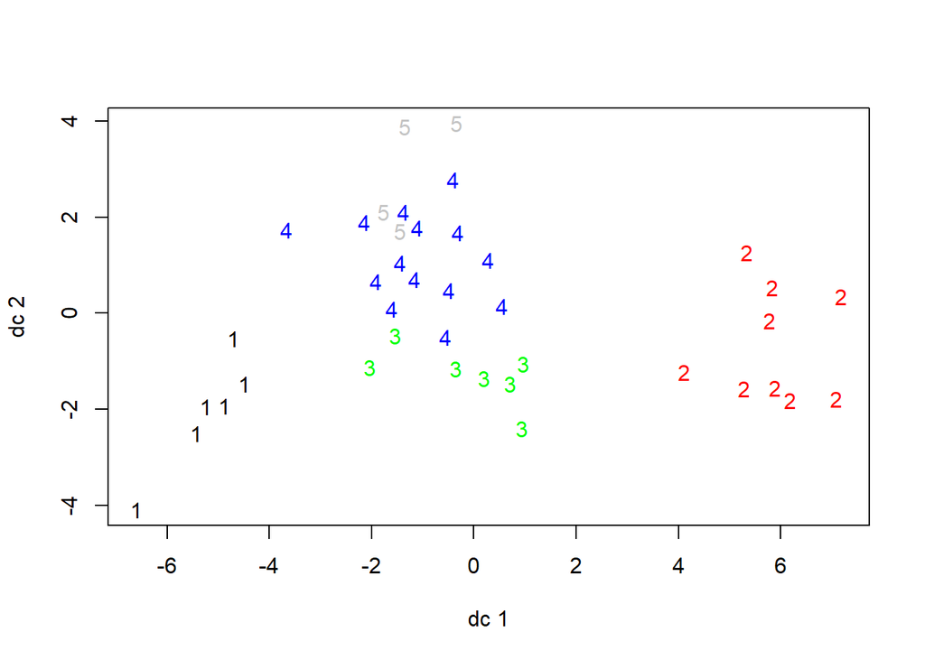

```r
plotcluster(players_normal, clusters$cluster)
```

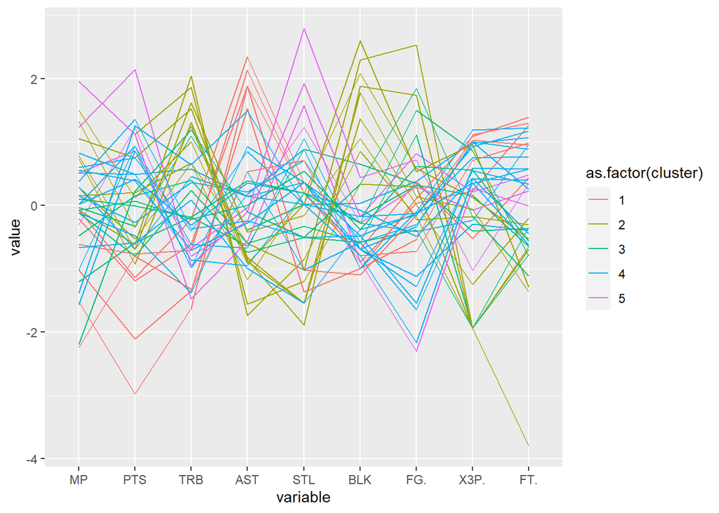

```r
ggparcoord(data=resultado,columns=2:10, groupColumn=1,mapping=aes(color=as.factor(cluster)))
```

Cálculo de los valores óptimos de K

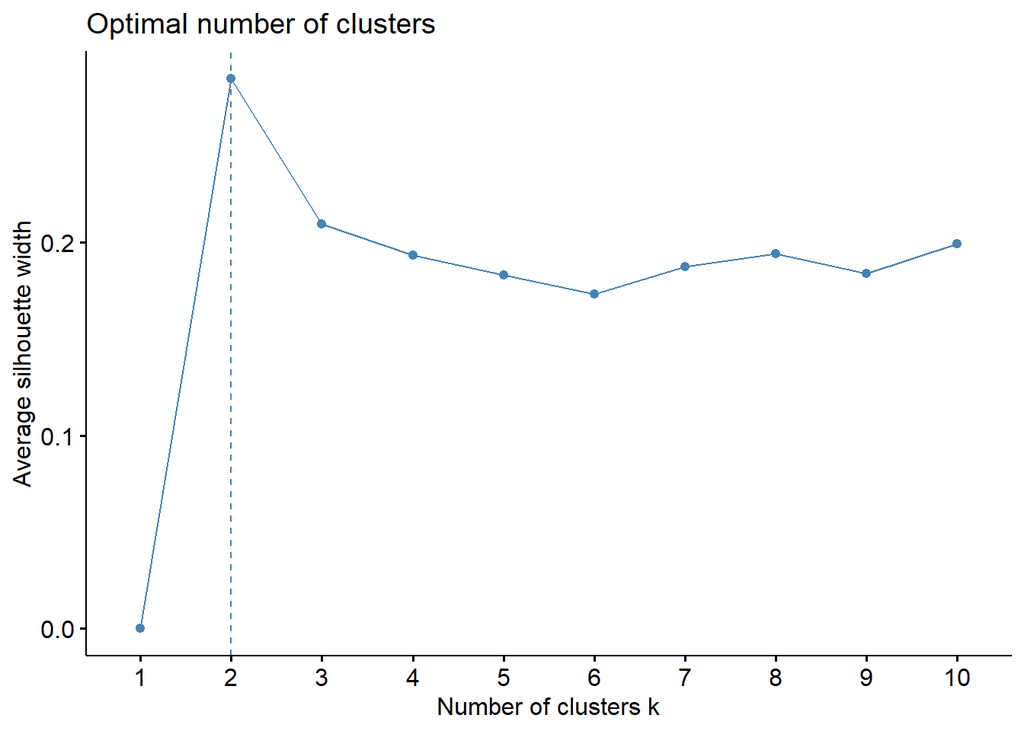

```r
# evaluacion modelo #1
# cálculo del score Silhouette
score_sil<- silhouette(clusters$cluster,daisy(players_normal))

# cálculo del valor óptimo de k usando el score silhouette
fviz_nbclust(players_normal,kmeans,method = 'silhouette',k.max = 10)
```

> El método “Average silhouette” determina el número óptimo de clusters k=2, donde se maximiza el valor de la silueta con respecto a un rango de valores k.

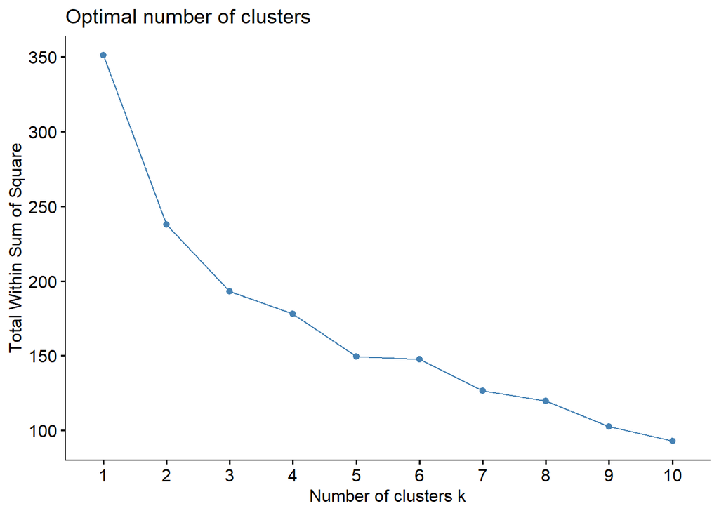

```r
# cálculo del valor óptimo de k usando el método del codo
fviz_nbclust(players_normal,kmeans,method = 'wss',k.max = 10)
```

> Evaluando la curva de la suma de cuadrados, podemos apreciar que en 2, 3, y 5 se encuentra levemente la figura que busca el método del “codo”, aunque es subjetivo, en el punto donde se dobla la linea es considerado como un buen indicar para estimar el número apropiado de clusters.

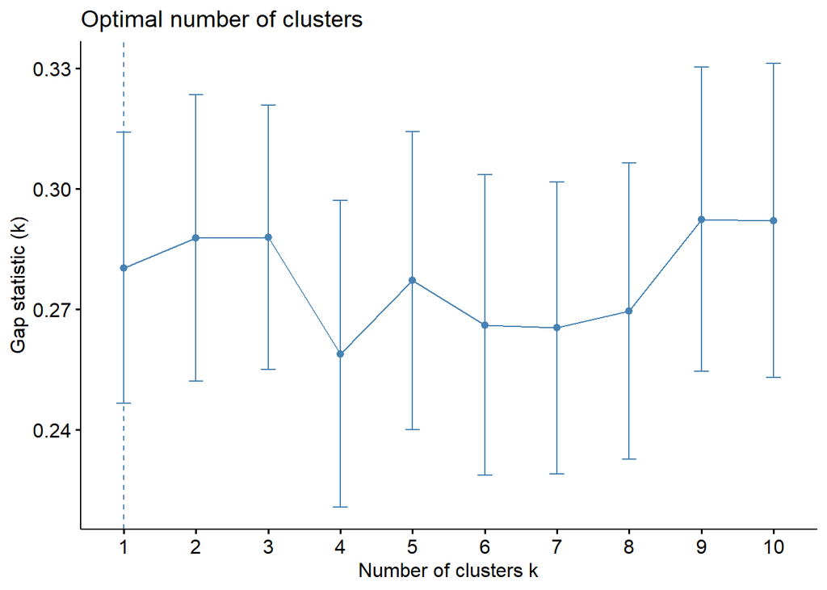

```r
# cálculo del valor óptimo de k usando la estadística gap
fviz_nbclust(players_normal,kmeans,method = 'gap_stat',k.max = 10)
```

> “Statistic gap” compara el total de variación intra-cluster, para diferentes valores de k, el valor óptimo que maximiza el espacio estadístico, esto significa que la estructura del cluster esta lejos de una distribución uniforme de puntos aleatorios.

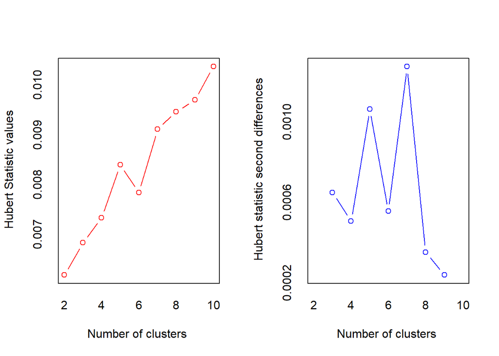

```
## *** : The Hubert index is a graphical method of determining the number of clusters.
##                 In the plot of Hubert index, we seek a significant knee that corresponds to a
##                 significant increase of the value of the measure i.e the significant peak in Hubert
##                 index second differences plot.
##
```

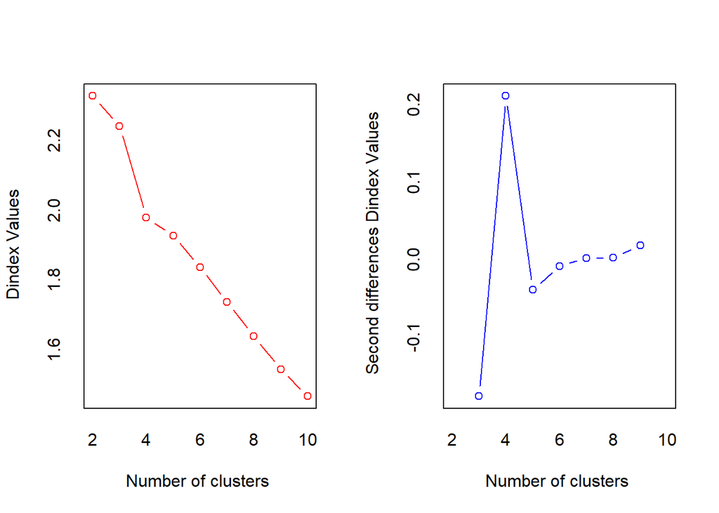

```
## *** : The D index is a graphical method of determining the number of clusters.
##                 In the plot of D index, we seek a significant knee (the significant peak in Dindex
##                 second differences plot) that corresponds to a significant increase of the value of
##                 the measure.
##
## * Among all indices:
## * 10 proposed 2 as the best number of clusters
## * 2 proposed 3 as the best number of clusters
## * 8 proposed 4 as the best number of clusters
## * 2 proposed 9 as the best number of clusters
## * 2 proposed 10 as the best number of clusters
##
##                    ***** Conclusion *****
##
## * According to the majority rule, the best number of clusters is  2
##
##
```

```
## $All.index
##         KL      CH Hartigan     CCC    Scott      Marriot    TrCovW   TraceW
## 2  14.2183 18.1088   2.8199 -0.7020  67.1370 2.625435e+12 1148.3371 237.7166
## 3   0.1025 10.8432  11.0460 -3.0535  99.8922 2.604646e+12 1047.5952 221.2946
## 4  26.9082 12.7157   2.1393 -1.4737 204.7734 3.364293e+11  514.4757 170.4181
## 5   0.1476 10.3428   3.5830 -2.6304 211.9240 4.396190e+11  485.7320 160.8590
## 6   0.7514  9.5568   4.1609 -2.9531 226.0610 4.445785e+11  353.5641 145.9209
## 7   0.9904  9.3488   4.1683 -2.8665 296.8138 1.031937e+11  304.3689 130.0103
## 8   2.4521  9.3294   2.1491 -2.3689 312.6697 9.067433e+10  211.6530 115.4300
## 9   0.4935  8.6995   3.5021 -2.7329 341.2588 5.615482e+10  187.0096 108.1657
## 10  1.2757  8.7054   2.8909 -2.4236 407.9851 1.307467e+10  167.9662  97.1865
##    Friedman  Rubin Cindex     DB Silhouette   Duda Pseudot2   Beale Ratkowsky
## 2    7.6455 1.4765 0.3519 1.3586     0.2847 0.7894   2.9341  1.4683    0.3717
## 3    9.1443 1.5861 0.3440 1.6652     0.2242 0.5553  16.0166  4.6240    0.3325
## 4   22.9830 2.0596 0.4414 1.5718     0.1732 1.2694  -2.1224 -1.1152    0.3530
## 5   19.5767 2.1820 0.4241 1.4999     0.1882 1.7369  -3.3940 -1.9107    0.3251
## 6   20.9880 2.4054 0.4304 1.3188     0.1596 1.6295  -1.9317 -1.5466    0.3099
## 7   30.4366 2.6998 0.3875 1.3485     0.1537 0.4191   8.3172  7.3992    0.2970
## 8   31.3943 3.0408 0.5020 1.2411     0.1808 6.9804   0.0000  0.0000    0.2883
## 9   35.4048 3.2450 0.4992 1.0726     0.2298 1.5812  -2.9406 -1.7658    0.2760
## 10  45.1438 3.6116 0.4587 1.0925     0.2321 1.8539  -4.1454 -2.0744    0.2679
##        Ball Ptbiserial    Frey McClain   Dunn Hubert SDindex Dindex   SDbw
## 2  118.8583     0.5165  1.4777  0.5729 0.2071 0.0062  1.3337 2.3262 0.7613
## 3   73.7649     0.5098  0.9762  0.6900 0.2071 0.0068  1.5710 2.2403 0.7532
## 4   42.6045     0.4349 -0.6109  2.1938 0.2429 0.0073  1.5484 1.9783 0.5910
## 5   32.1718     0.4804 -3.0470  1.9840 0.2985 0.0084  1.5669 1.9267 0.6267
## 6   24.3201     0.4186  0.1981  2.5646 0.2429 0.0078  1.3574 1.8359 0.5184
## 7   18.5729     0.4224 -0.3966  3.2310 0.2941 0.0091  1.5004 1.7367 0.4936
## 8   14.4287     0.4595  0.0823  2.9480 0.3098 0.0095  1.3214 1.6390 0.4352
## 9   12.0184     0.4604  0.3790  2.9650 0.3098 0.0097  1.2376 1.5437 0.2902
## 10   9.7187     0.4299  0.8666  4.0382 0.3819 0.0104  1.3010 1.4667 0.2746
##
## $All.CriticalValues
##    CritValue_Duda CritValue_PseudoT2 Fvalue_Beale
## 2          0.5302             9.7481       0.1703
## 3          0.6523            10.6590       0.0000
## 4          0.4496            12.2415       1.0000
## 5          0.2857            19.9974       1.0000
## 6          0.2098            18.8341       1.0000
## 7          0.4742             6.6522       0.0000
```

[output cut: 84 more lines]

```
##                                                 2
##          LeBron James ( 2012-13 ) - Small forward
##                                                 2
##          Kevin Durant ( 2013-14 ) - Small forward
##                                                 2
##           Stephen Curry ( 2014-15 ) - Point guard
##                                                 2
##           Stephen Curry ( 2015-16 ) - Point guard
##                                                 2
##       Russell Westbrook ( 2016-17 ) - Point guard
##                                                 2
##         James Harden ( 2017-18 ) - Shooting guard
##                                                 2
## Giannis Antetokounmpo ( 2018-19 ) - Power forward
##                                                 1
```

```r
NbClust(data = players_normal, diss = NULL, distance = "euclidean", min.nc = 2, max.nc = 10, method = "kmeans")
```

Los parámetros a utilizar son: k = 2 centroides, siguiendo la recomendación dada por silhouette para el primer modelo. nstart = 15 configuraciones iniciales, aprovechando el tamaño del set de datos y la reducción en la cantidad de centroides a utilizar.

```r
# ejecución del algoritmo kmeans con los parámetros elegidos
clusters2 <- kmeans(players_normal,2,nstart=15)

# obtener cantidad de registros en cada cluster y los centroides
descClusters2<- data.frame(clusters2$size,clusters2$centers)
kable(descClusters2)
```

| clusters2.size | MP | PTS | TRB | AST | STL | BLK | FG. | X3P. | FT. |
| --- | --- | --- | --- | --- | --- | --- | --- | --- | --- |
| 13 | 0.3757827 | -0.1285489 | 1.1433064 | -0.8310068 | -0.7161316 | 1.0187554 | 0.6401445 | -0.9248501 | -0.9543185 |
| 27 | -0.1809324 | 0.0618939 | -0.5504809 | 0.4001144 | 0.3448041 | -0.4905118 | -0.3082177 | 0.4452982 | 0.4594867 |

```r
# crear un data frame combinando el cluster asignado y los atributos originales
resultado2 <- data.frame(clusters2$cluster,players_normal)
names(resultado2)[1] <- "cluster"
kable(resultado2[order(resultado2$cluster),])
```

|  | cluster | MP | PTS | TRB | AST | STL | BLK | FG. | X3P. | FT. |
| --- | --- | --- | --- | --- | --- | --- | --- | --- | --- | --- |
| Kareem Abdul-Jabbar ( 1979-80 ) - Center | 1 | 0.2855046 | -0.5351316 | 0.6678360 | -0.6016506 | -1.0228546 | 2.2912116 | 2.5288635 | -1.9367814 | -0.6463440 |
| Moses Malone ( 1981-82 ) - Center | 1 | 1.9556499 | 1.1215413 | 1.8612198 | -1.5600320 | -1.1962198 | 0.3390582 | 0.2967410 | -1.9367814 | -0.6855956 |
| Moses Malone ( 1982-83 ) - Center | 1 | -0.0756079 | -0.6140208 | 2.0448173 | -1.7375100 | -0.8494894 | 0.8527828 | -0.1759438 | -1.9367814 | -0.6986795 |
| Charles Barkley ( 1992-93 ) - Power forward | 1 | -0.0304689 | -0.3247605 | 1.0962302 | -0.3886769 | 0.0173365 | -0.1746664 | 0.3230013 | 0.1628039 | -0.6463440 |
| Hakeem Olajuwon ( 1993-94 ) - Center | 1 | 1.5042593 | 0.1222782 | 1.0044314 | -0.9211110 | 0.0173365 | 2.5994464 | 0.5330834 | 0.9613347 | -1.2874544 |
| David Robinson ( 1994-95 ) - Center | 1 | 0.1500874 | 0.2011674 | 0.6678360 | -1.1695803 | 0.1907017 | 2.0857218 | 0.5856039 | 0.1283845 | -0.5285890 |
| Karl Malone ( 1996-97 ) - Power forward | 1 | -0.4818595 | 0.1485746 | 0.3924397 | -0.6016506 | -0.3293938 | -0.5856460 | 1.1108092 | -1.9367814 | -0.7771828 |
| Karl Malone ( 1998-99 ) - Power forward | 1 | -0.1207470 | -0.7980956 | 0.2394418 | -0.7436330 | -0.5027590 | -0.5856460 | -0.3860259 | -1.9367814 | -0.3454146 |
| Shaquille O’Neal ( 1999-00 ) - Center | 1 | 1.0528687 | 0.7533917 | 1.5246244 | -0.8501198 | -1.8896805 | 1.8802320 | 1.7410556 | -1.9367814 | -3.7995606 |
| Tim Duncan ( 2001-02 ) - Power forward | 1 | 1.3237030 | -0.3510569 | 1.2492281 | -0.8856154 | -1.5429501 | 1.3665074 | 0.0078781 | -1.2483928 | -0.2014918 |
| Tim Duncan ( 2002-03 ) - Power forward | 1 | 0.7368952 | -0.9295776 | 1.3104273 | -0.8146242 | -1.5429501 | 1.7774871 | 0.1391794 | -0.0574804 | -1.3659577 |
| Kevin Garnett ( 2003-04 ) - Power forward | 1 | 0.7820343 | -0.6929100 | 1.6164231 | -0.4241725 | -0.1560287 | 1.0582726 | -0.2284643 | -0.1745065 | -0.3061629 |
| Giannis Antetokounmpo ( 2018-19 ) - Power forward | 1 | -2.1971439 | 0.2274638 | 1.1880289 | -0.1047120 | -0.5027590 | 0.3390582 | 1.8460966 | -0.1745065 | -1.1173639 |
| Julius Erving ( 1980-81 ) - Small forward | 2 | -1.2040845 | -0.5877244 | -0.1889524 | -0.6371462 | 0.8841624 | 0.6472930 | 0.3492615 | -0.4085586 | -0.3584985 |
| Larry Bird ( 1983-84 ) - Small forward | 2 | 0.2855046 | -0.6929100 | 0.4536389 | 0.1437572 | 0.3640669 | -0.2774113 | -0.4122862 | -0.2364615 | 0.9629740 |
| Larry Bird ( 1984-85 ) - Small forward | 2 | 0.8271733 | 0.4904278 | 0.5760372 | 0.1437572 | 0.0173365 | 0.0308235 | 0.3755218 | 1.0026380 | 0.8844707 |
| Larry Bird ( 1985-86 ) - Small forward | 2 | 0.1500874 | -0.2721677 | 0.3618401 | 0.2147484 | 0.7107973 | -0.5856460 | -0.3072451 | 0.9751025 | 1.0676451 |
| Magic Johnson ( 1986-87 ) - Point guard | 2 | -0.6172767 | -0.7717992 | -0.7091454 | 2.1315112 | 0.1907017 | -0.6883909 | 0.3755218 | -0.5255847 | 0.4396186 |
| Michael Jordan ( 1987-88 ) - Shooting guard | 2 | 1.2334249 | 2.1471007 | -0.9539421 | -0.1047120 | 2.7911795 | 0.4418031 | 0.7169052 | -1.0281084 | 0.3480314 |
| Magic Johnson ( 1988-89 ) - Point guard | 2 | -0.0756079 | -1.1399487 | -0.2195520 | 2.3444849 | 0.3640669 | -0.8938808 | 0.0341383 | 0.2247589 | 1.2639034 |
| Magic Johnson ( 1989-90 ) - Point guard | 2 | -0.2110251 | -1.1925415 | -0.6173466 | 1.8830420 | 0.1907017 | -0.7911359 | -0.7274093 | 0.7066309 | 0.9891418 |
| Michael Jordan ( 1990-91 ) - Shooting guard | 2 | -0.3013032 | 1.2267268 | -0.8009442 | -0.2466945 | 1.9243535 | -0.1746664 | 0.8219463 | 0.2109911 | 0.4788702 |
| Michael Jordan ( 1991-92 ) - Shooting guard | 2 | 0.5111999 | 0.8585773 | -0.6785458 | -0.0337208 | 1.2308928 | -0.2774113 | 0.2967410 | -0.0781321 | 0.2302764 |
| Michael Jordan ( 1995-96 ) - Shooting guard | 2 | 0.0146702 | 0.9374665 | -0.6173466 | -0.6726418 | 1.0575276 | -0.6883909 | -0.3335054 | 1.0026380 | 0.2564442 |
| Michael Jordan ( 1997-98 ) - Shooting guard | 2 | 0.5111999 | 0.4904278 | -0.8621433 | -0.9566066 | 0.1907017 | -0.6883909 | -1.1213133 | -0.2984165 | -0.3977501 |
| Allen Iverson ( 2000-01 ) - Shooting guard | 2 | 1.9556499 | 1.1215413 | -1.4741350 | -0.5661549 | 1.5776232 | -0.8938808 | -2.3030252 | 0.2660622 | -0.0052336 |
| Steve Nash ( 2004-05 ) - Point guard | 2 | -1.5200580 | -2.9806964 | -1.6271330 | 1.8830420 | -1.0228546 | -1.0993706 | -0.1496835 | 1.0301736 | 0.9498901 |
| Steve Nash ( 2005-06 ) - Point guard | 2 | -1.0235283 | -2.1129153 | -1.3517367 | 1.5280859 | -1.3695850 | -0.9966257 | 0.1129191 | 1.0852447 | 1.3947423 |
| Dirk Nowitzki ( 2006-07 ) - Power forward | 2 | -0.6624158 | -0.5877244 | 0.0864438 | -0.9921022 | -1.5429501 | -0.3801562 | -0.1496835 | 0.9269153 | 1.1723162 |
| Kobe Bryant ( 2007-08 ) - Shooting guard | 2 | 0.5563390 | 0.3852422 | -0.7091454 | -0.2821901 | 0.3640669 | -0.6883909 | -1.2788749 | 0.5483015 | 0.3349475 |
| LeBron James ( 2008-09 ) - Small forward | 2 | 0.0146702 | 0.4115386 | -0.3113508 | 0.3567309 | 0.1907017 | -0.0719214 | -0.4910670 | 0.4312755 | -0.4500857 |
| LeBron James ( 2009-10 ) - Small forward | 2 | 0.6014780 | 0.7533917 | -0.4031495 | 0.8536694 | 0.0173365 | -0.1746664 | -0.1234232 | 0.3555527 | -0.6201762 |
| Derrick Rose ( 2010-11 ) - Point guard | 2 | -0.1207470 | -0.4825389 | -1.3823363 | 0.5342089 | -1.0228546 | -0.5856460 | -1.6465186 | 0.3486688 | 0.5704574 |
| LeBron James ( 2011-12 ) - Small forward | 2 | -0.0756079 | 0.0696854 | -0.2195520 | 0.0017748 | 0.5374321 | -0.3801562 | 0.6118642 | 0.5551854 | -0.5678407 |
| LeBron James ( 2012-13 ) - Small forward | 2 | 0.1049483 | -0.0092037 | -0.1889524 | 0.3922265 | 0.1907017 | -0.2774113 | 1.5047132 | 0.8580764 | -0.8033506 |
| Kevin Durant ( 2013-14 ) - Small forward | 2 | 0.3757827 | 1.3582088 | -0.3725500 | -0.2466945 | -0.5027590 | -0.4829011 | -0.1234232 | 0.7548181 | 0.7667157 |
| Stephen Curry ( 2014-15 ) - Point guard | 2 | -2.2422830 | -0.7980956 | -1.3211371 | 0.5342089 | 0.7107973 | -0.9966257 | -0.5435875 | 1.1127802 | 1.3031551 |
| Stephen Curry ( 2015-16 ) - Point guard | 2 | -1.5651970 | 0.8585773 | -0.9845417 | 0.1792528 | 0.8841624 | -0.9966257 | -0.0971630 | 1.1885029 | 1.2246518 |
| Russell Westbrook ( 2016-17 ) - Point guard | 2 | -1.3846408 | 1.2530232 | 0.6372364 | 1.4925903 | 0.0173365 | -0.7911359 | -2.1717239 | 0.4243916 | 0.4003669 |
| James Harden ( 2017-18 ) - Shooting guard | 2 | -1.0235283 | 0.9374665 | -0.9845417 | 0.9246606 | 0.3640669 | -0.4829011 | -1.5414776 | 0.5896048 | 0.5704574 |

- *Descripción del modelo obtenido (incluya al menos un gráfico por modelo)*

> La ejecución del modelo nos da como resultado 2 clusters de 27 y de 13 elementos.

> A diferencia del primer modelo de k=5, éste utiliza los rebotes (TRB), asistencias (AST), robos (STL) y bloqueos (BLK) como las dimensiones más importantes para el agrupamiento. Con mucha seguridad, incluso antes de ver el dataframe “resultado2”, podríamos concluir que el algoritmo está dividiendo entre bases (point guard, shooting guard, small foward) y aleros (power forward y center). También se le llama a esta diferenciación “hombres pequeños” y “hombres grandes”, respectivamente.

> A continuación, el primer gráfico nos muestra la distribución de los jugadores en los distintos clusters:

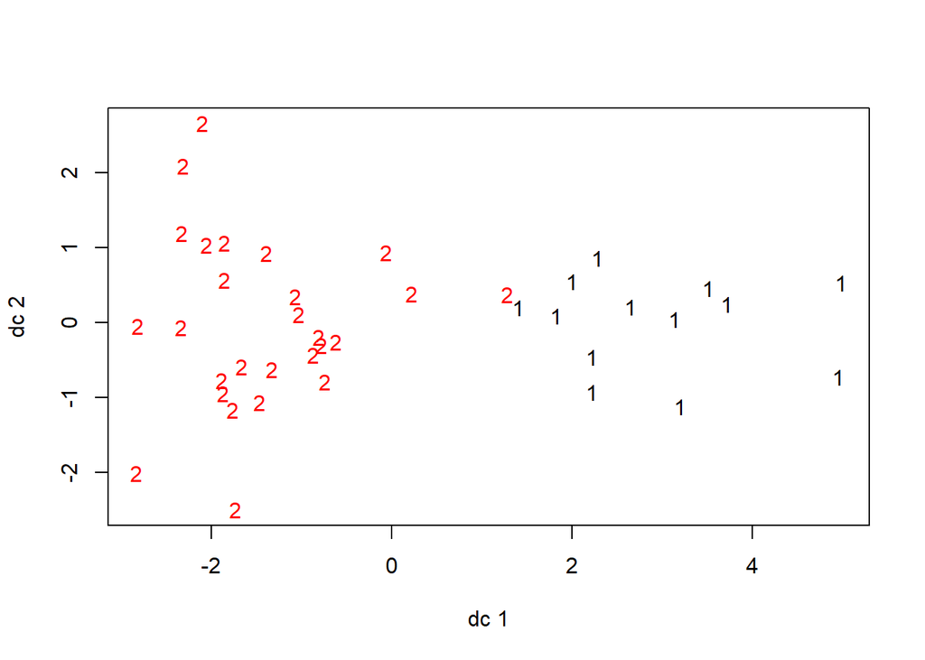

```r
plotcluster(players_normal, clusters2$cluster)
```

> El segundo gráfico nos muestra el aporte o influencia de cada una de las dimensiones para la clasificación de los jugadores, cada línea representa a un jugador y está coloreada de acuerdo al cluster en el que fue colocado. La única diferencia de este gráfico respecto al producido por el modelo anterior es obviamente la cantidad de colores/clusters.

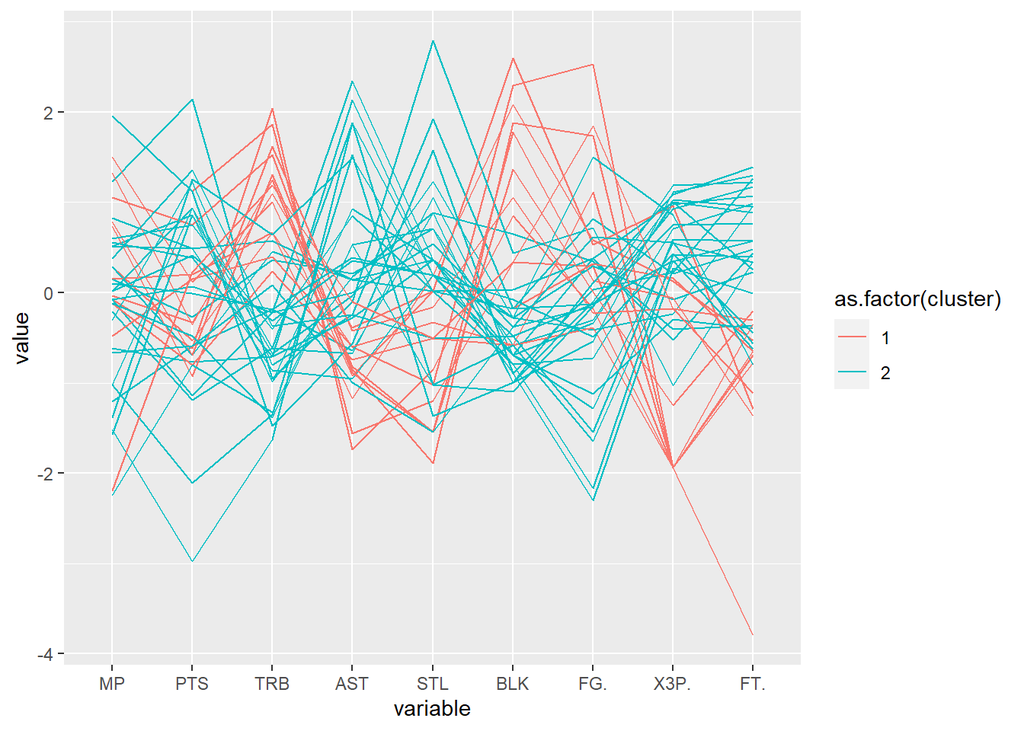

```r
ggparcoord(data=resultado2,columns=2:10, groupColumn=1,mapping=aes(color=as.factor(cluster)))
```

#### Construcción de modelo Jerárquico

Reconocido como uno de los modelos más utilizados en agrupaciones de objectos, con base en su similitud. Tambien es conocido como AGNES (Agglomerative Nesting). El algoritmo inicia tratando cada objecto como un cluster único. Luego, crea parejas de clusters que son combinadas, hasta que todos se hayan constituido en un gran cluster conteniendo todos los objetos. El resultado es una representación tipo árbol de todos los elementos, llamado dendrogram.

De esta forma el algoritmo funciona como “bottom-up”, inicia en las hojas, donde cada elemento es un cluster por si mismo y continua haciendo agregaciones. En cada paso, los dos clusters con mayor similitud son combinados en un cluster de mayor altura en la jerarquía. El proceso se repite hasta que se obtiene un único cluster raíz.

- Cálculo de la matriz de distancias euclidianas.

```r
# se calculan las distancias entre los puntos
    dist_matrix<- dist(players_normal,method = 'euclidean')
    as.matrix(dist_matrix)[1:10, 1:10]
```

```
##                                             Kareem Abdul-Jabbar ( 1979-80 ) - Center
## Kareem Abdul-Jabbar ( 1979-80 ) - Center                                    0.000000
## Julius Erving ( 1980-81 ) - Small forward                                   4.057728
## Moses Malone ( 1981-82 ) - Center                                           4.086744
## Moses Malone ( 1982-83 ) - Center                                           3.569417
## Larry Bird ( 1983-84 ) - Small forward                                      4.824846
## Larry Bird ( 1984-85 ) - Small forward                                      4.870426
## Larry Bird ( 1985-86 ) - Small forward                                      5.620483
## Magic Johnson ( 1986-87 ) - Point guard                                     5.328761
## Michael Jordan ( 1987-88 ) - Shooting guard                                 5.833941
## Magic Johnson ( 1988-89 ) - Point guard                                     6.047867
##                                             Julius Erving ( 1980-81 ) - Small forward
## Kareem Abdul-Jabbar ( 1979-80 ) - Center                                     4.057728
## Julius Erving ( 1980-81 ) - Small forward                                    0.000000
## Moses Malone ( 1981-82 ) - Center                                            4.982836
## Moses Malone ( 1982-83 ) - Center                                            3.639984
## Larry Bird ( 1983-84 ) - Small forward                                       2.595017
## Larry Bird ( 1984-85 ) - Small forward                                       3.339461
## Larry Bird ( 1985-86 ) - Small forward                                       2.981955
## Magic Johnson ( 1986-87 ) - Point guard                                      3.351210
## Michael Jordan ( 1987-88 ) - Shooting guard                                  4.357355
## Magic Johnson ( 1988-89 ) - Point guard                                      4.030852
##                                             Moses Malone ( 1981-82 ) - Center
## Kareem Abdul-Jabbar ( 1979-80 ) - Center                             4.086744
## Julius Erving ( 1980-81 ) - Small forward                            4.982836
## Moses Malone ( 1981-82 ) - Center                                    0.000000
## Moses Malone ( 1982-83 ) - Center                                    2.794839
## Larry Bird ( 1983-84 ) - Small forward                               4.460036
## Larry Bird ( 1984-85 ) - Small forward                               4.348055
## Larry Bird ( 1985-86 ) - Small forward                               5.197112
## Magic Johnson ( 1986-87 ) - Point guard                              6.056563
## Michael Jordan ( 1987-88 ) - Shooting guard                          5.440312
## Magic Johnson ( 1988-89 ) - Point guard                              6.427410
##                                             Moses Malone ( 1982-83 ) - Center
## Kareem Abdul-Jabbar ( 1979-80 ) - Center                             3.569417
## Julius Erving ( 1980-81 ) - Small forward                            3.639984
## Moses Malone ( 1981-82 ) - Center                                    2.794839
## Moses Malone ( 1982-83 ) - Center                                    0.000000
## Larry Bird ( 1983-84 ) - Small forward                               3.829587
## Larry Bird ( 1984-85 ) - Small forward                               4.539711
```

[output cut: 55 more lines]

```
## Larry Bird ( 1985-86 ) - Small forward                                         4.452307
## Magic Johnson ( 1986-87 ) - Point guard                                        5.042120
## Michael Jordan ( 1987-88 ) - Shooting guard                                    0.000000
## Magic Johnson ( 1988-89 ) - Point guard                                        5.441117
##                                             Magic Johnson ( 1988-89 ) - Point guard
## Kareem Abdul-Jabbar ( 1979-80 ) - Center                                   6.047867
## Julius Erving ( 1980-81 ) - Small forward                                  4.030852
## Moses Malone ( 1981-82 ) - Center                                          6.427410
## Moses Malone ( 1982-83 ) - Center                                          5.929446
## Larry Bird ( 1983-84 ) - Small forward                                     2.551322
## Larry Bird ( 1984-85 ) - Small forward                                     3.284846
## Larry Bird ( 1985-86 ) - Small forward                                     2.571203
## Magic Johnson ( 1986-87 ) - Point guard                                    1.464679
## Michael Jordan ( 1987-88 ) - Shooting guard                                5.441117
## Magic Johnson ( 1988-89 ) - Point guard                                    0.000000
```

```r
# se establece el criterio de linkage y se ejecuta el clustering
clustJer_conWard<- hclust(dist_matrix,method = 'ward.D')
```

> La funcion de enlace toma la informacion de la distancia, retornada por la funcion dist(), y agrupa pares de objetos dentro de clusters con base en su similitud. Algunas variantes para el método disponibles en la función hclust son: “ward.D”, “ward.D2”, “single”, “complete”, “average”, “mcquitty”, “median” o “centroid”.

##### Visualización del cluster

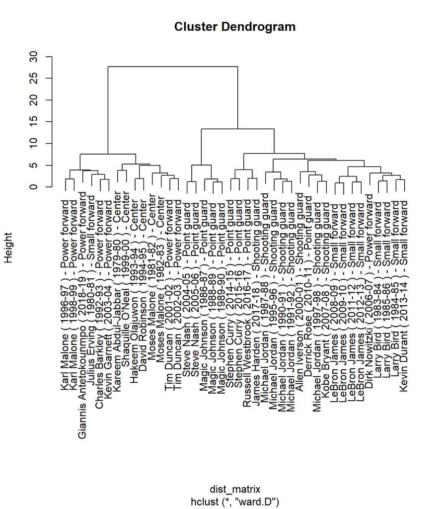

```r
# dendrograma del clustering  usando average
plot(clustJer_conWard)
```

> Debido a la naturaleza del algorimo, es esperado que un jugador que sea nominado múltiples años, inicie formando un cluster consigo mismo, en otra temporada, siempre y cuando sus estadisticas sean consistentes. De hecho se puede apreciar este efecto en jugadores como LeBron llegando a formar 2 niveles, combinandose el mismo en dos ocasiones. Es muy comun ese patrón en el primer nivel.

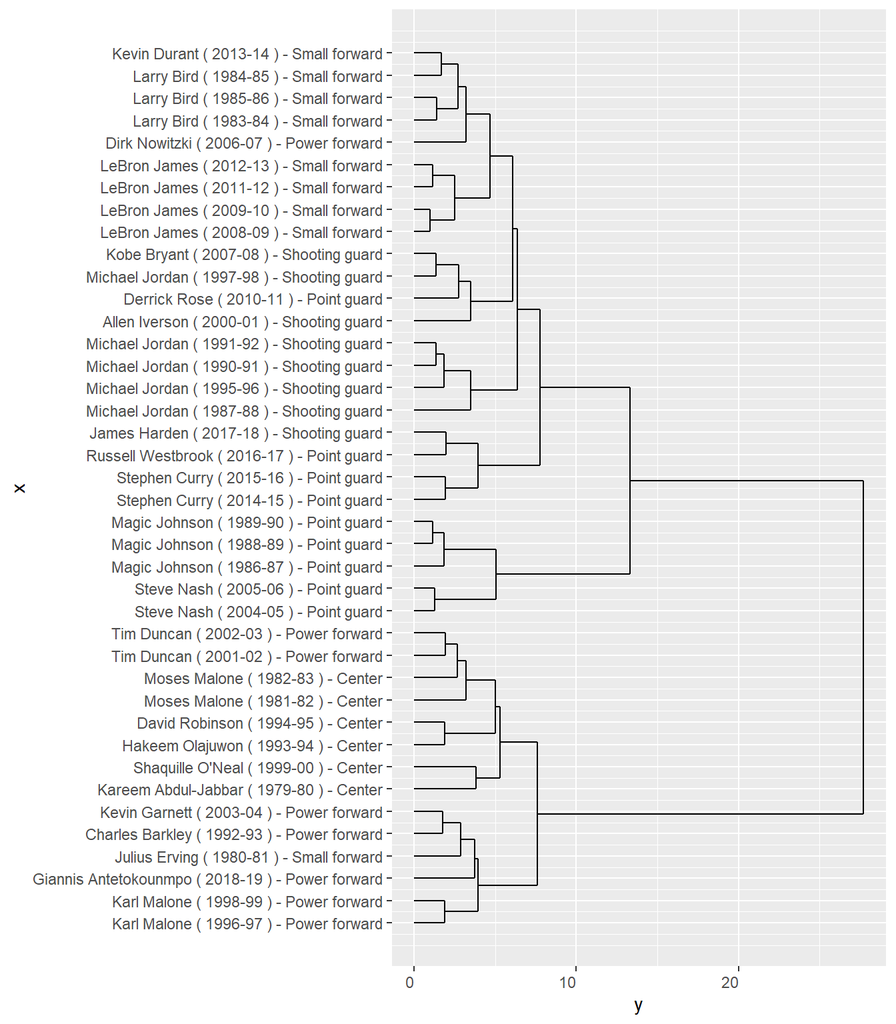

```r
#dendrograma<-as.dendrogram(clustJer_conWard)
#color_dendro<- color_branches(dendrograma,k=5)
#plot(color_dendro, cex=0.6)

ggdendrogram(clustJer_conWard, rotate = TRUE, theme_dendro = FALSE)
```

```r
# Horizontal plot
# Build dendrogram object from hclust results
#dend <- as.dendrogram(clustJer_conWard)
#dend %>% set("branches_k_color", k = 5) %>% plot(horiz = TRUE)
#dend %>% rect.dendrogram(k = 5, horiz = TRUE, border = 8, lty = 5, lwd = 2)
```

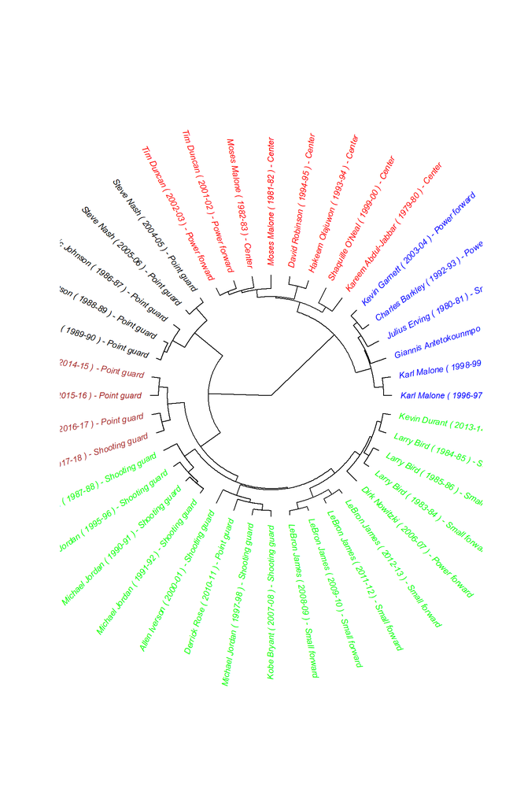

```r
colors = c("red", "blue", "green", "black", "brown")
clus5 = cutree(clustJer_conWard, 5)
plot(as.phylo(clustJer_conWard), type = "fan", tip.color = colors[clus5], label.offset = 1, cex = 0.7)
```

##### DIvisive clustering

Existe una version “top-down” que inicia en la raíz llamado “divisive clustering”, donde el cluster más heterogeneo es dividido en dos, y el proceso continua hasta obtener las hojas.

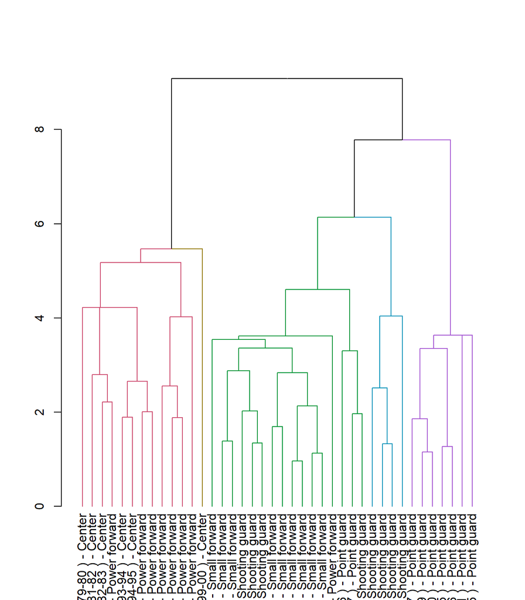

```r
# DIvisive ANAlysis Clustering
res.diana <- diana(x = players_normal, # data matrix
                   stand = FALSE, # standardize the data
                   metric = "ward.D2" # metric for distance matrix
                   )
#fviz_dend(res.diana, cex = 0.5)
#plot(res.diana)
dendrograma <- as.dendrogram(res.diana)
color_dendro<- color_branches(dendrograma,k=5)
plot(color_dendro)
```

```r
#ggdendrogram(res.diana, rotate = TRUE, theme_dendro = FALSE)
```

- *Evaluación de los modelos*

Los modelos obtenidos utilizando k-means arrojan resultados muy similares a los que una persona “manualmente” realizaría: separar a los jugadores por “roles” (k=2) o por posición (k=5), con la salvedad de que el algoritmo obviamente desconoce estas clasificaciones prácticas y utiliza únicamente las estadísticas para agrupar, lo que explica por que existen algunos “intrusos” en grupos en los que, según su posición, no corresponderían. Dirk Nowitzki es por supuesto el mejor ejemplo de esta “equivocación” al encontrarse en un grupo que con coincide con su posición, pero conociendo la carrera del jugador alemán uno sabe que nunca fue un “hombre grande” tradicional; al contrario se caraterizaba por su efectivo tiro desde el exterior y zona de 3 puntos y su pobre desempeño en estadísticas tradicionales de los power forwards: rebotes y bloqueos.

Los modelos k-means nos brindan resultados muy claros pues se basan en una interpretación muy directa/simple de las estadísticas. Esto claramente es deseable cuando se requiera agrupar de forma simple un gran número de elementos con una cantidad de dimensiones no trivial.

El modelo jerárquico inicialmente presentó falta de precisión agrupando con el método de promedio, sin embargo el método WARD.D presenta muy buenos resultados, es evidente como la diferencia estadística entre el mismo jugador durante diferentes temporadas, tienden a agruparse, como reflejo de la consistencia de sus habilidades.